# ICESat-2 and GEDI against airborne lidar at Québec’s permanent forest plots

The whole exercise, step by step, with the complete code

João Paulo Czarnecki de Liz (developer), with Claude (Anthropic) as coding assistant

2026-11-11

This file runs the exercise of the [tutorial](https://joaoczarnecki.github.io/ICESAT_GEDI_ALS_FRI_QUEBEC_Exercise/) one step at a time. Every chunk holds the **complete code** of a script from `scripts/`; nothing is hidden behind `source()`. R chunks run in this R session. Python chunks (marked `py`) run with the exercise’s Python. Each step shows what it produced and ends with `check_step()`, which tests the files before you go on.

With the default parameters, the heavy steps use the tables provided in `data/` instead of rebuilding them: steps 1–3, 5, 6, 9 and 10. Knitting then takes a few minutes. Set the parameters in the header to `true` to rebuild them: *Knit → Knit with Parameters* in RStudio, or `rmarkdown::render("exercise.Rmd", params = list(run_download = TRUE))`. The only download needed with the defaults is the PEP GeoPackage, used for the forest types in step 7. See the [data page](https://joaoczarnecki.github.io/ICESAT_GEDI_ALS_FRI_QUEBEC_Exercise/01_setup_and_data.html).

To run a chunk on its own in RStudio, run the `setup` chunk and the two helper chunks below first.

# Helpers

## Checks of each step (`scripts/check_data.R`)

```r
###############################################################################
# check_data.R - check the inputs and outputs of each step before moving on
#
# Author:    João Paulo Czarnecki de Liz (developer)
# Co-author: Claude (Anthropic), AI coding assistant
# Licence:   MIT (see LICENSE)
#
# Every check prints PASS, WARN or FAIL with a one-line reason. FAIL = the next step will not work or its results
# would be wrong; WARN = it will run, but look at the reason. Steps whose files are absent are reported as SKIP.
#
# Run   Rscript scripts/check_data.R          all steps whose files are present
#       Rscript scripts/check_data.R 5        one step (0 = software, 1-11 = the numbered scripts)
# Use   source("scripts/check_data.R"); check_step(3)          (from R or the R Markdown exercise)
###############################################################################
suppressPackageStartupMessages({ library(data.table) })
ROOT <- Sys.getenv("EXERCISE_ROOT", ".")
f_ <- function(...) file.path(ROOT, ...)
PEP_GPKG <- Sys.getenv("PEP_GPKG", f_("data/raw/PEP.gpkg"))
IDX_GPKG <- Sys.getenv("LIDAR_INDEX_GPKG", f_("data/raw/Index_Lidar.gpkg"))
LAZ_DIR  <- Sys.getenv("LAZ_DIR", f_("data/raw/laz"))
PY <- Sys.getenv("PY", if (.Platform$OS.type == "windows") f_(".venv/Scripts/python.exe") else f_(".venv/bin/python"))

.res <- NULL
chk <- function(step, what, ok, msg = "", warn = FALSE) {
  status <- if (isTRUE(ok)) "PASS" else if (warn) "WARN" else "FAIL"
  .res <<- rbind(.res, data.frame(step = step, status = status, check = what, detail = msg))
  cat(sprintf("  [%s] %s%s\n", status, what, if (nzchar(msg)) paste0(" - ", msg) else ""))
  invisible(isTRUE(ok))
}
skip <- function(step, what) { .res <<- rbind(.res, data.frame(step = step, status = "SKIP", check = what, detail = "file not found"))
  cat(sprintf("  [SKIP] %s - file not found\n", what)) }
has_cols <- function(d, cols) { m <- setdiff(cols, names(d)); if (length(m)) paste("missing:", paste(m, collapse = ", ")) else "" }
pct <- function(x) sprintf("%.1f%%", 100 * x)
als_table <- function() {                          # the ALS table actually used downstream
  full <- f_("data/derived/plot_als_metrics_full.csv")
  if (file.exists(full)) list(d = fread(full), src = full, own = TRUE) else list(d = fread(f_("data/plot_als_metrics.csv")), src = "data/plot_als_metrics.csv", own = FALSE)
}

why_dir <- function() {                            # step 9-10 tables: yours, else the provided ones
  w <- Sys.getenv("WHY_DIR", f_("data/derived/why"))
  if (file.exists(file.path(w, "plots_upe.csv"))) w else f_("data/why")
}

check_step <- function(step) {
  cat(sprintf("\nStep %s\n", step))
  switch(as.character(step),
  "0" = {
    pk <- c("lidR", "RCSF", "sf", "curl", "data.table", "ggplot2", "patchwork", "scales", "rnaturalearth", "rnaturalearthhires")
    miss <- pk[!vapply(pk, requireNamespace, logical(1), quietly = TRUE)]
    chk(0, "R packages", !length(miss), if (length(miss)) paste("install:", paste(miss, collapse = ", ")) else paste(length(pk), "found"))
    if (!file.exists(PY)) chk(0, "Python", FALSE, sprintf("not found at %s (create .venv or set PY=/path/to/python)", PY))
    else {
      out <- tryCatch(system2(PY, c("-I", "-c", shQuote("import sliderule, geopandas, pyarrow; print(sliderule.__version__, geopandas.__version__)")),
                              stdout = TRUE, stderr = TRUE), error = function(e) conditionMessage(e))
      chk(0, "Python packages (sliderule, geopandas, pyarrow)", is.null(attr(out, "status")), paste(tail(out, 1)))
    }
  },
  "1" = {
    if (!file.exists(PEP_GPKG)) skip(1, "data/raw/PEP.gpkg") else {
      ly <- sf::st_layers(PEP_GPKG)$name
      chk(1, "PEP.gpkg layers", all(c("placette", "placette_mes", "dendro_arbres", "classi_eco_pe") %in% ly),
          has_cols(setNames(as.list(ly), ly), c("placette", "placette_mes", "dendro_arbres", "classi_eco_pe")))
    }
    if (!file.exists(IDX_GPKG)) skip(1, "data/raw/Index_Lidar.gpkg (only needed to rebuild the ALS table)") else {
      ly <- sf::st_layers(IDX_GPKG)
      chk(1, "Index_Lidar.gpkg has layer Index_Tuiles_LiDAR", "Index_Tuiles_LiDAR" %in% ly$name)
    }
    pt <- f_("data/derived/plot_tiles.csv")
    if (!file.exists(pt)) skip(1, "data/derived/plot_tiles.csv") else {
      d <- fread(pt)
      chk(1, "plot_tiles.csv columns", has_cols(d, c("plot_id", "NOM_TUILE", "CODE_EPSG", "DATES_ACQUISITION", "url", "TYPE_DONNEES")) == "",
          has_cols(d, c("plot_id", "NOM_TUILE", "CODE_EPSG", "DATES_ACQUISITION", "url", "TYPE_DONNEES")))
      chk(1, "one row per plot", !anyDuplicated(d$plot_id), sprintf("%s plots", format(nrow(d), big.mark = ",")))
      chk(1, "plots with a tile", mean(!is.na(d$NOM_TUILE)) > 0.8, pct(mean(!is.na(d$NOM_TUILE))), warn = TRUE)
      e <- unique(na.omit(d$CODE_EPSG))
      chk(1, "EPSG codes are Quebec MTM zones (2943-2952)", all(e >= 2943 & e <= 2952), paste(sort(e), collapse = " "))
      chk(1, "download URLs", all(grepl("^https?://", na.omit(d$url))), "")
    }
  },
  "2" = {
    pt <- f_("data/derived/plot_tiles.csv")
    if (!dir.exists(LAZ_DIR) || !file.exists(pt)) skip(2, "data/raw/laz/ and plot_tiles.csv") else {
      d <- fread(pt)[!is.na(tile_file_name) & TYPE_DONNEES == "Données classifiées"]
      need <- unique(d$tile_file_name); have <- file.exists(file.path(LAZ_DIR, need))
      chk(2, "tiles on disk", all(have), sprintf("%s of %s", format(sum(have), big.mark = ","), format(length(need), big.mark = ",")), warn = TRUE)
      sz <- file.info(file.path(LAZ_DIR, need[have]))$size
      chk(2, "no empty file", !any(sz == 0), sprintf("%d empty", sum(sz == 0)))
      if (any(have)) {
        s <- sample(need[have], min(3, sum(have)))
        ok <- vapply(s, function(f) !inherits(tryCatch(lidR::readLASheader(file.path(LAZ_DIR, f)), error = function(e) e), "error"), logical(1))
        chk(2, "LAZ headers readable (3 random tiles)", all(ok), paste(s[!ok], collapse = ", "))
      }
    }
  },
  "3" = {
    a <- als_table(); d <- a$d
    cat("  using", a$src, "\n")
    chk(3, "ALS columns", has_cols(d, c("plot_id", "zq50", "zq95", "zmax", "pt_density_m2")) == "", has_cols(d, c("plot_id", "zq50", "zq95", "zmax", "pt_density_m2")))
    if ("status" %in% names(d)) {
      chk(3, "plots with status ok", mean(d$status == "ok") > 0.9, pct(mean(d$status == "ok")), warn = TRUE)
      cat("  status:", paste(names(table(d$status)), table(d$status), collapse = "; "), "\n")
      d <- d[status == "ok"]
    }
    chk(3, "heights within 0-60 m", all(d$zq95 >= 0 & d$zmax <= 60, na.rm = TRUE), sprintf("zq95 %.1f-%.1f m", min(d$zq95), max(d$zq95)))
    chk(3, "zq50 <= zq95 <= zmax", all(d$zq50 <= d$zq95 + 1e-9 & d$zq95 <= d$zmax + 1e-9, na.rm = TRUE), "")
    chk(3, "point density", median(d$pt_density_m2) > 1, sprintf("median %.1f pts/m2 in the plots", median(d$pt_density_m2)), warn = TRUE)
  },
  "4" = {
    b <- f_("data/derived/plot_buffers_150m.gpkg")
    if (!file.exists(b)) skip(4, "data/derived/plot_buffers_150m.gpkg") else {
      g <- sf::st_read(b, quiet = TRUE); a <- als_table()$d; if ("status" %in% names(a)) a <- a[status == "ok"]
      chk(4, "one buffer per plot with ALS", nrow(g) == nrow(a) && !anyDuplicated(g$plot_id), sprintf("%s buffers, %s plots", nrow(g), nrow(a)))
      ar <- as.numeric(sf::st_area(sf::st_transform(g[sample(nrow(g), min(200, nrow(g))), ], 32198)))
      chk(4, "buffer area = pi x 150^2", all(abs(ar / (pi * 150^2) - 1) < 0.02), sprintf("%.0f m2 (median)", median(ar)))
      chk(4, "valid geometries", all(sf::st_is_valid(g)), "")
    }
  },
  "5" = {
    a <- als_table()$d
    for (p in c("gedi02a", "atl08")) {
      f <- f_("data/derived", paste0(p, "_plots.csv")); if (!file.exists(f)) f <- f_("data/satellite", paste0(p, "_plots.csv"))
      if (!file.exists(f)) { skip(5, paste0(p, "_plots.csv")); next }
      d <- fread(f, colClasses = list(character = intersect(c("time", "time_ns"), names(fread(f, nrows = 1)))))
      need <- if (p == "gedi02a") c("plot_id", "time", "beam", "orbit", "rh50", "rh95", "rh98", "sensitivity", "leaf_off_flag", "flags", "lon", "lat")
              else c("plot_id", "time_ns", "rgt", "gt", "spot", "h_canopy", "segment_snowcover", "lon", "lat")
      chk(5, paste(p, "columns"), has_cols(d, need) == "", has_cols(d, need))
      chk(5, paste(p, "plot_id all in the ALS table"), all(d$plot_id %in% a$plot_id), sprintf("%s rows, %s plots", format(nrow(d), big.mark = ","), format(uniqueN(d$plot_id), big.mark = ",")))
      tcol <- if (p == "gedi02a") "time" else "time_ns"
      yr <- as.integer(substr(d[[tcol]], 1, 4)); mo <- as.integer(substr(d[[tcol]], 6, 7))
      chk(5, paste(p, "years 2019-2025"), all(yr >= 2018 & yr <= 2025), paste(range(yr), collapse = "-"))
      chk(5, paste(p, "months June-September"), mean(mo %in% 6:9) > 0.98, sprintf("%s outside (granules selected by date)", pct(mean(!mo %in% 6:9))), warn = TRUE)
      key <- if (p == "gedi02a") c("plot_id", "time", "beam") else c("plot_id", "time_ns", "rgt", "gt", "segment_id_beg")
      chk(5, paste(p, "no duplicated sample x plot"), !anyDuplicated(d[, intersect(key, names(d)), with = FALSE]), "")
      if (p == "gedi02a") {
        chk(5, "GEDI south of 51.6 N", all(d$lat <= 51.7), sprintf("max lat %.2f", max(d$lat)))
        chk(5, "GEDI server filters applied (flags: bit 0 off, bit 1 on)", all(bitwAnd(d$flags, 1L) == 0 & bitwAnd(d$flags, 2L) == 2), "")
        chk(5, "GEDI RH95 within -5..60 m", mean(d$rh95 >= -5 & d$rh95 <= 60) > 0.99, sprintf("%.2f%% outside", 100 * mean(!(d$rh95 >= -5 & d$rh95 <= 60))), warn = TRUE)
      } else {
        chk(5, "ATL08 h_canopy within 0..60 m (or NA = no canopy)", mean(is.na(d$h_canopy) | (d$h_canopy >= 0 & d$h_canopy <= 60)) > 0.99, "", warn = TRUE)
      }
      cache <- f_("data/derived", paste0(p, "_plots_cache"))
      if (dir.exists(cache)) chk(5, paste(p, "download chunks cached"), TRUE, sprintf("%d chunks", length(list.files(cache, "_20[0-9]{2}[.]parquet$"))))
    }
  },
  "6" = {
    f <- f_("data/derived/plot_mrnf_events.csv"); if (!file.exists(f)) f <- f_("data/plot_mrnf_events.csv")
    d <- fread(f); a <- als_table()$d
    cat("  using", f, "\n")
    chk(6, "event columns", has_cols(d, c("plot_id", "layer", "exercice", "origine", "an_origine", "perturb", "an_perturb", "overlap")) == "",
        has_cols(d, c("plot_id", "layer", "exercice", "origine", "an_origine", "perturb", "an_perturb", "overlap")))
    chk(6, "overlap in [0, 1]", all(d$overlap >= 0 & d$overlap <= 1),
        sprintf("%d slivers round to 0; step 7 keeps events covering >= 50%% of the plot", sum(d$overlap == 0)))
    chk(6, "plot_id all in the ALS table", all(d$plot_id %in% a$plot_id), sprintf("%s events on %s plots", format(nrow(d), big.mark = ","), format(uniqueN(d$plot_id), big.mark = ",")))
    chk(6, "known layers", all(d$layer %in% c("ca_interv_for_close_scale", "ca_feu_close_scale", "ca_perturb_autre_close_scale")), "")
  },
  "7" = {
    f <- f_("data/derived/plots_province.csv")
    if (!file.exists(f)) skip(7, "data/derived/plots_province.csv") else {
      d <- fread(f); a <- als_table()$d; if ("status" %in% names(a)) a <- a[status == "ok"]
      chk(7, "one row per plot with ALS", nrow(d) == nrow(a) && !anyDuplicated(d$plot_id), sprintf("%s rows", format(nrow(d), big.mark = ",")))
      chk(7, "forest type assigned", mean(!is.na(d$forest_type)) > 0.95, pct(mean(!is.na(d$forest_type))), warn = TRUE)
      cat("  forest types:", paste(names(table(d$forest_type)), table(d$forest_type), collapse = "; "), "\n")
      chk(7, "ALS dates 2009-2025", all(d$als_year >= 2009 & d$als_year <= 2025), paste(range(d$als_year), collapse = "-"))
      chk(7, "field measurement near the ALS", median(abs(d$field_year - d$als_year), na.rm = TRUE) <= 6,
          sprintf("median %d years apart", as.integer(median(abs(d$field_year - d$als_year), na.rm = TRUE))), warn = TRUE)
      e <- f_("data/derived/plot_events_2010plus.csv")
      if (file.exists(e)) chk(7, "events since 2010", TRUE, sprintf("%s plots", format(uniqueN(fread(e)$plot_id), big.mark = ",")))
```

```r
    }
  },
  "8" = {
    figs <- f_("docs/assets/img", paste0(c("P1_plots_with_samples", "P2_agreement_at_the_plot", "P3_delay_uncertainty", "P4_forest_type_and_als_season"), ".png"))
    chk(8, "figures written", all(file.exists(figs)), paste(basename(figs[!file.exists(figs)]), collapse = ", "))
    n <- f_("outputs/numbers.txt")
    if (!file.exists(n)) skip(8, "outputs/numbers.txt") else {
      x <- readLines(n); chk(8, "numbers written", length(x) > 10, sprintf("%d lines", length(x)))
      for (p in c("pairs_gedi.csv", "pairs_atl08.csv")) if (file.exists(f_("outputs", p))) {
        d <- fread(f_("outputs", p)); chk(8, paste(p, "distances <= 100 m"), all(d$dist <= 100), sprintf("%s pairs", format(nrow(d), big.mark = ",")))
      }
    }
  },
  "9" = {
    chk(9, "study area polygon", file.exists(f_("data/study_area/upe1415_study_area.shp")))
    W <- why_dir()
    for (s in c("gedi02a.csv", "atl08.csv")) {
      p <- file.path(Sys.getenv("WHY_SAT_DIR", f_("data/derived/why")), s)
      if (!file.exists(p)) skip(9, paste("region satellite download", s, "(only needed to rebuild step 9)"))
      else chk(9, paste("region download", s), nrow(fread(p, select = 1L)) > 1000, sprintf("%s rows", format(nrow(fread(p, select = 1L)), big.mark = ",")))
    }
    if (!file.exists(file.path(W, "plots_upe.csv"))) skip(9, file.path(W, "plots_upe.csv")) else {
      p <- fread(file.path(W, "plots_upe.csv")); t <- fread(file.path(W, "tiles_upe.csv"))
      chk(9, "region plots with ALS and forest type", nrow(p) > 300 && !anyNA(p$forest_type), sprintf("%d plots in %d tiles", nrow(p), nrow(t)))
      chk(9, "every plot's tile is listed", all(p$tile_file_name %in% t$tile_file_name))
      g <- fread(file.path(W, "samples_gedi.csv"), select = c("tile_file_name", "x_tile", "y_tile", "post_als_event"))
      a <- fread(file.path(W, "samples_atl08.csv"), select = c("tile_file_name", "ux", "uy", "post_als_event"))
      tg <- merge(g, t[, .(tile_file_name, hdr_xmin, hdr_xmax, hdr_ymin, hdr_ymax)], by = "tile_file_name")
      chk(9, "GEDI footprints wholly inside their tile",
          all(tg$x_tile - 12.5 >= tg$hdr_xmin & tg$x_tile + 12.5 <= tg$hdr_xmax & tg$y_tile - 12.5 >= tg$hdr_ymin & tg$y_tile + 12.5 <= tg$hdr_ymax),
          sprintf("%s footprints", format(nrow(g), big.mark = ",")))
      chk(9, "ATL08 along-track direction is a unit vector", all(abs(sqrt(a$ux^2 + a$uy^2) - 1) < 1e-3), sprintf("%s segments", format(nrow(a), big.mark = ",")))
      chk(9, "post-ALS events flagged", mean(g$post_als_event != "none") < 0.2, sprintf("GEDI %s with an event", pct(mean(g$post_als_event != "none"))), warn = TRUE)
    }
  },
  "10" = {
    W <- why_dir()
    if (!file.exists(file.path(W, "als_at_gedi.csv"))) skip(10, file.path(W, "als_at_gedi.csv")) else {
      g <- fread(file.path(W, "als_at_gedi.csv")); s <- fread(file.path(W, "samples_gedi.csv"), select = "time")
      chk(10, "ALS computed for the GEDI footprints", nrow(g) / nrow(s) > 0.95, sprintf("%s of %s", format(nrow(g), big.mark = ","), format(nrow(s), big.mark = ",")), warn = TRUE)
      chk(10, "GEDI footprints with enough ALS returns", mean(g$als_n >= 100, na.rm = TRUE) > 0.95, pct(mean(g$als_n >= 100, na.rm = TRUE)), warn = TRUE)
      a <- fread(file.path(W, "als_at_atl08.csv"))
      chk(10, "ALS heights within 0-60 m", all(between(c(g$als_rh98, a$als_p98_can), 0, 60), na.rm = TRUE))
      pc <- merge(fread(file.path(W, "als_at_plots_check.csv")), als_table()$d[, .(plot_id, zq95)], by = "plot_id")
      e <- sqrt(mean((pc$als_rh95 - pc$zq95)^2, na.rm = TRUE))
      chk(10, "plot P95 matches the ALS table (same LAZ, other ground filter)", e < 0.5, sprintf("RMSE %.2f m over %d plots", e, nrow(pc)))
    }
  },
  "11" = {
    figs <- f_("docs/assets/img/why", paste0(c("13_footprint_agreement", "17_plot_level_comparison"), ".png"))
    chk(11, "figures written", all(file.exists(figs)), paste(basename(figs[!file.exists(figs)]), collapse = ", "))
    n <- f_("outputs/why/numbers_why.txt")
    if (!file.exists(n)) skip(11, "outputs/why/numbers_why.txt") else {
      fa <- fread(f_("outputs/why/footprint_agreement.csv"))
      chk(11, "footprint agreement for 8 metrics", nrow(fa) == 8 && all(fa$n > 1000), sprintf("GEDI RH98 RMSE %.1f m", fa[metric == "rh98"]$rmse))
    }
  })
  invisible(.res[.res$step == step, ])
}
```

## Reading and filtering the satellite tables (`scripts/summarise_lidar_by_polygon.R`)

Used by steps 8 and 11.

```r
###############################################################################
# summarise_lidar_by_polygon.R - per-polygon canopy metrics from 05_get_spaceborne_lidar.py output
#
# Author:    João Paulo Czarnecki de Liz (developer)
# Co-author: Claude (Anthropic), AI coding assistant
# Licence:   MIT (see LICENSE)
#
#   source("scripts/summarise_lidar_by_polygon.R")
#   d <- read_lidar("out/atl08.csv")                      # csv (base R) or parquet (needs arrow)
#   s <- lidar_summary(d, product = "atl08", id = "site",
#                      periods = list(pre = 2019:2022, post = 2024:2025))
#   ch <- lidar_change(s, id = "site")                    # post - pre per polygon
#
#   # ANY other set of polygons, e.g. a 5 km hexagon grid over a study area (needs sf):
#   hex <- lidar_hexgrid(sf::st_read("study_area.shp"), cell_km = 5)
#   d   <- lidar_assign(d, hex, id = "cell")              # adds the 'cell' column (point-in-polygon)
#   s   <- lidar_summary(d, product = "atl08", id = "cell")
#
# Functions
#   read_lidar()      read the csv / parquet written by 05_get_spaceborne_lidar.py
#   lidar_filter()    product-specific quality filters (called by lidar_summary; usable alone)
#   lidar_summary()   metrics per polygon x period, with pass-level bootstrap 95% CIs
#   lidar_change()    wide table + differences between two periods
#   lidar_assign()    attach samples to any polygon layer (sf), e.g. stands, plots, grid cells
#   lidar_hexgrid()   hexagon grid clipped to an area, ready for lidar_assign()
#
# Metrics per polygon x period
#   n          samples kept after filtering (ATL08 100 m segments / GEDI ~25 m shots)
#   n_passes   independent passes (ATL08: rgt + beam + date; GEDI: orbit + beam) - the REAL
#              sample size: samples along one pass are spatially autocorrelated
#   cover      share of samples with canopy height >= cover_thr (default 2 m)        [atl08, gedi02a]
#   cover_tall share of samples >= tall_thr (default 5 m; no CI). GEDI rarely reports RH98 < 2-3 m,
#              so GEDI cover at 2 m saturates near 100%: use cover_tall to compare the sensors
#   h_med      median canopy height of canopy samples (ATL08 h_canopy = RH98; GEDI rh98)
#   h_p90      90th percentile of canopy height (a 'dominant height' style metric)
#   agbd_mean  mean above-ground biomass density, Mg/ha                              [gedi04a]
#   *_lo/_hi   95% CI from a bootstrap that resamples whole passes (resampling single samples
#              would treat 100 segments of one pass as 100 independent draws -> CIs far too narrow)
#   flag_low_n TRUE when n < min_n or n_passes < min_passes - treat as indicative only
#
# Filters (defaults follow the ATL08 / GEDI user guides; adjust for your biome)
#   atl08   snow-free (segment_snowcover == 1); strong beams (spot 1, 3, 5) unless beams = "all";
#           night passes only if night_only = TRUE (solar_elevation < 0: no sunlight noise);
#           h_canopy NA -> 0 m (ATL08 found no canopy photons = open ground); h_canopy <= max_h
#   gedi02a leaf-on (leaf_off_flag == 0); sensitivity >= min_sens; optional full-power beams only
#           (beam 5, 6, 8, 11); rh98 <= max_h. Degrade + L2A quality filters ran at download.
#   gedi04a leaf-on; sensitivity >= min_sens; degrade + L4A quality filters ran at download.
###############################################################################

read_lidar <- function(file) {
  if (grepl("\\.parquet$", file)) {
    if (!requireNamespace("arrow", quietly = TRUE)) file <- sub("\\.parquet$", ".csv", file)
    else return(as.data.frame(arrow::read_parquet(file)))
  }
  read.csv(file)
}

detect_product <- function(d) {
  if ("h_canopy" %in% names(d)) "atl08" else if ("agbd" %in% names(d)) "gedi04a" else "gedi02a"
}

lidar_filter <- function(d, product = detect_product(d), max_h = 60, min_sens = 0.95,
                         beams = c("strong", "all"), night_only = FALSE, power_beams_only = FALSE) {
  beams <- match.arg(beams)
  if (product == "atl08") {
    d <- d[d$segment_snowcover == 1, ]
    if (beams == "strong") d <- d[d$spot %in% c(1, 3, 5), ]
    if (night_only) d <- d[d$solar_elevation < 0, ]
    d$h <- ifelse(is.na(d$h_canopy), 0, d$h_canopy)          # no canopy photons -> 0 m
    d <- d[d$h <= max_h, ]
    d$time <- d$time_ns
    d$pass <- paste(d$rgt, d$gt, substr(d$time, 1, 10))      # one beam on one date
  } else {
    if ("leaf_off_flag" %in% names(d)) d <- d[d$leaf_off_flag == 0, ]
    d <- d[d$sensitivity >= min_sens, ]
    if (power_beams_only) d <- d[d$beam %in% c(5, 6, 8, 11), ]
    if (product == "gedi02a") { d$h <- pmax(d$rh98, 0); d <- d[d$h <= max_h, ] }
    d$pass <- paste(d$orbit, d$beam)                          # one beam on one orbit
  }
  d$year <- as.integer(substr(d$time, 1, 4))
  d
}

boot_pass <- function(x, pass, fun, B = 500) {
  if (length(unique(pass)) < 3) return(c(NA, NA))            # too few passes for a CI
  idx <- split(seq_along(x), pass)
  v <- replicate(B, { s <- unlist(idx[sample(length(idx), replace = TRUE)], use.names = FALSE); fun(x[s]) })
  unname(quantile(v, c(0.025, 0.975), na.rm = TRUE))
}

lidar_summary <- function(x, product = NULL, id, periods = list(all = 2018:2035), cover_thr = 2, tall_thr = 5,
                          min_n = 50, min_passes = 3, B = 500, seed = 1, filter = TRUE, ...) {
  d <- if (is.character(x)) read_lidar(x) else x
  if (is.null(product)) product <- detect_product(d)
  product <- match.arg(product, c("atl08", "gedi02a", "gedi04a"))
  set.seed(seed)
  if (filter) d <- lidar_filter(d, product, ...)
  d <- d[!is.na(d[[id]]), ]
  d$period <- NA_character_
  for (p in names(periods)) d$period[d$year %in% periods[[p]]] <- p
  d <- d[!is.na(d$period), ]
  cov_fun <- function(h) mean(h >= cover_thr)
  med_fun <- function(h) median(h[h >= cover_thr])
  p90_fun <- function(h) unname(quantile(h[h >= cover_thr], 0.9))
  out <- lapply(split(d, list(d[[id]], d$period), drop = TRUE), function(g) {
    r <- data.frame(id = g[[id]][1], period = g$period[1], n = nrow(g), n_passes = length(unique(g$pass)))
    if (product == "gedi04a") {
      ci <- boot_pass(g$agbd, g$pass, mean, B)
      r <- cbind(r, agbd_mean = mean(g$agbd), agbd_lo = ci[1], agbd_hi = ci[2])
    } else {
      ci_c <- boot_pass(g$h, g$pass, cov_fun, B); ci_h <- boot_pass(g$h, g$pass, med_fun, B)
      r <- cbind(r, cover = cov_fun(g$h), cover_lo = ci_c[1], cover_hi = ci_c[2], cover_tall = mean(g$h >= tall_thr),
                 h_med = med_fun(g$h), h_lo = ci_h[1], h_hi = ci_h[2],
                 h_p90 = if (any(g$h >= cover_thr)) p90_fun(g$h) else NA)
    }
    r$flag_low_n <- r$n < min_n | r$n_passes < min_passes
    r
  })
  out <- do.call(rbind, out); names(out)[1] <- id; rownames(out) <- NULL
  out[order(out[[id]], match(out$period, names(periods))), ]
}

lidar_change <- function(s, id, from = "pre", to = "post") {
  w <- reshape(s[, setdiff(names(s), "flag_low_n")], idvar = id, timevar = "period", direction = "wide")
  for (m in intersect(c("cover", "h_med", "h_p90", "agbd_mean"), names(s)))
    w[[paste0("d_", m)]] <- w[[paste0(m, ".", to)]] - w[[paste0(m, ".", from)]]
  w
}

lidar_assign <- function(d, polys, id) {
  pts <- sf::st_as_sf(d, coords = c("lon", "lat"), crs = 4326, remove = FALSE)
  pts <- sf::st_transform(pts, sf::st_crs(polys))
  hit <- sf::st_intersects(pts, polys)
  d[[id]] <- polys[[id]][vapply(hit, function(i) if (length(i)) i[1] else NA_integer_, integer(1))]
  d
}

lidar_hexgrid <- function(area, cell_km = 5, crs = NULL) {
  if (!is.null(crs)) area <- sf::st_transform(area, crs)
  if (sf::st_is_longlat(area)) stop("Project 'area' to a metric CRS first (or pass crs =).")
  a <- sf::st_union(area)
  # sf's hexagon 'cellsize' is the flat-to-flat width; this width gives each hexagon the area of a
  # cell_km x cell_km square (cell_km = 5 -> 25 km2 cells)
  g <- sf::st_make_grid(a, cellsize = cell_km * 1000 * sqrt(2 / sqrt(3)), square = FALSE)
  g <- g[lengths(sf::st_intersects(g, a)) > 0]
  hex <- sf::st_sf(cell = seq_along(g), geometry = g)
  suppressWarnings(sf::st_intersection(hex, a))   # clip edge cells to the area
}
```

# Step 0. Software

Python: `python -m venv .venv`, then `.venv/Scripts/python -m pip install -r requirements.txt` (`.venv/bin/python` on Linux and macOS). R packages:

```r
###############################################################################
# 00_install_r_packages.R - R packages used by the exercise (tested with R 4.6.2 on Windows)
#
# Author:    João Paulo Czarnecki de Liz (developer)
# Co-author: Claude (Anthropic), AI coding assistant
# Licence:   MIT (see LICENSE)
#
# Run once: Rscript scripts/00_install_r_packages.R
###############################################################################
pk <- c("lidR",                    # point clouds: read LAZ, ground classification, normalisation, metrics
        "RCSF",                    # cloth simulation filter, used by lidR::csf() (not installed with lidR)
        "sf", "curl",              # vector data, downloads
        "data.table",              # fast tables
        "ggplot2", "patchwork", "scales",          # figures
        "rnaturalearth", "rnaturalearthhires")     # Québec outline for the maps
miss <- setdiff(pk, rownames(installed.packages()))
if ("rnaturalearthhires" %in% miss) {           # not on CRAN
  install.packages("rnaturalearthhires", repos = "https://ropensci.r-universe.dev")
  miss <- setdiff(miss, "rnaturalearthhires")
}
if (length(miss)) install.packages(miss, repos = "https://cloud.r-project.org")
for (p in pk) cat(sprintf("%-20s %s\n", p, if (requireNamespace(p, quietly = TRUE)) as.character(packageVersion(p)) else "MISSING"))
```

```r
check_step(0)
```

```
Step 0
  [PASS] R packages - 10 found
  [PASS] Python packages (sliderule, geopandas, pyarrow) - 5.8.1 1.2.0
```

# Steps 1–3. ALS metrics of each plot

## Step 1. Match the plots to the lidar tiles

```r
###############################################################################
# 01_match_plots_to_tiles.R - find the airborne lidar (ALS) tile that covers each Québec permanent sample plot
#
# Author:    João Paulo Czarnecki de Liz (developer)
# Co-author: Claude (Anthropic), AI coding assistant
# Licence:   MIT (see LICENSE)
#
# Reads the PEP plot layer and the provincial lidar tile index, joins each plot to the tile(s) it falls in,
# keeps the most recent acquisition (PLUS_RECENTE = "Oui") and prefers classified point clouds over raw ones.
# The output lists, for each plot, the tile name, its EPSG zone, its acquisition date(s) and its download URL.
#
# Inputs  data/raw/PEP.gpkg          layer "placette" (Données Québec, Placettes-échantillons permanentes)
#         data/raw/Index_Lidar.gpkg  layer "Index_Tuiles_LiDAR" (Données Québec, Données lidar du Québec)
# Output  data/derived/plot_tiles.csv
# Run     Rscript scripts/01_match_plots_to_tiles.R          (~3 min; the tile index has ~900,000 polygons)
###############################################################################
suppressPackageStartupMessages({ library(sf) })
sf_use_s2(FALSE)
ROOT <- Sys.getenv("EXERCISE_ROOT", ".")
PEP  <- Sys.getenv("PEP_GPKG", file.path(ROOT, "data/raw/PEP.gpkg"))
IDX  <- Sys.getenv("LIDAR_INDEX_GPKG", file.path(ROOT, "data/raw/Index_Lidar.gpkg"))
OUT  <- file.path(ROOT, "data/derived"); dir.create(OUT, showWarnings = FALSE, recursive = TRUE)
stopifnot("Put PEP.gpkg in data/raw/ (see docs/01_setup_and_data.md)" = file.exists(PEP),
          "Put Index_Lidar.gpkg in data/raw/ (see docs/01_setup_and_data.md)" = file.exists(IDX))

plots <- st_read(PEP, layer = "placette", quiet = TRUE)
plots <- data.frame(plot_id = as.numeric(plots$id_pe), latitude = plots$latitude, longitude = plots$longitude)
plots <- st_as_sf(plots[!is.na(plots$latitude), ], coords = c("longitude", "latitude"), crs = 4326, remove = FALSE)
cat("PEP plots:", nrow(plots), "\n")

# Most recent acquisition only; if the SQL filter fails on the accented values, filter in R instead
tiles <- tryCatch(st_read(IDX, query = "SELECT * FROM Index_Tuiles_LiDAR WHERE PLUS_RECENTE = 'Oui'", quiet = TRUE),
                  error = function(e) NULL)
if (is.null(tiles) || !nrow(tiles)) {
  tiles <- st_read(IDX, layer = "Index_Tuiles_LiDAR", quiet = TRUE)
  tiles <- tiles[tiles$PLUS_RECENTE == "Oui", ]
}
cat("Tile records (most recent):", nrow(tiles), "\n")
tiles <- st_transform(tiles[, c("NOM_TUILE", "TELECHARGEMENT_TUILE", "PROJET", "TYPE_DONNEES", "DENSITE",
                                "CLASSIFICATION", "CODE_EPSG", "DATES_ACQUISITION", "CAPTEUR")], 4326)

j <- st_drop_geometry(st_join(plots, tiles, join = st_intersects, left = TRUE))
n_match <- table(j$plot_id)
# prefer classified ("Données classifiées") over raw ("Données brutes") when a plot falls in several records
j$type_rank <- ifelse(j$TYPE_DONNEES == "Données classifiées", 1L, ifelse(j$TYPE_DONNEES == "Données brutes", 2L, 3L))
j <- j[order(j$plot_id, j$type_rank), ]
best <- j[!duplicated(j$plot_id), ]
best$n_tile_matches <- as.integer(n_match[as.character(best$plot_id)])
best$url <- sub("\\?.*$", "", best$TELECHARGEMENT_TUILE)            # drop tracking parameters
best$tile_file_name <- ifelse(is.na(best$NOM_TUILE), NA, paste0(best$NOM_TUILE, ".LAZ"))
best$type_rank <- best$TELECHARGEMENT_TUILE <- NULL

write.csv(best, file.path(OUT, "plot_tiles.csv"), row.names = FALSE)
cat("Plots with a tile:", sum(!is.na(best$NOM_TUILE)), "| classified:",
    sum(best$TYPE_DONNEES == "Données classifiées", na.rm = TRUE),
    "| distinct tiles to download:", length(unique(na.omit(best$tile_file_name))), "\n")
cat("Acquisition years:\n"); print(table(substr(best$DATES_ACQUISITION, 1, 4)))
cat("Saved", file.path(OUT, "plot_tiles.csv"), "\n")
check_step(1)
```

## Step 2. Download the tiles

```r
###############################################################################
# 02_download_laz.R - download the lidar tiles (LAZ) listed by 01_match_plots_to_tiles.R
#
# Author:    João Paulo Czarnecki de Liz (developer)
# Co-author: Claude (Anthropic), AI coding assistant
# Licence:   MIT (see LICENSE)
#
# One tile is 1 km x 1 km (about 20-150 MB). The whole province (~11,000 tiles, ~1 TB) takes a day or more;
# use TILE_LIMIT to try a few first. Files already on disk are skipped, so the script can be stopped and rerun.
#
# Input   data/derived/plot_tiles.csv
# Output  data/raw/laz/<NOM_TUILE>.LAZ, data/derived/download_log.csv
# Run     Rscript scripts/02_download_laz.R                  (all tiles of classified point clouds)
#         TILE_LIMIT=20 WORKERS=4 Rscript scripts/02_download_laz.R
#         TILE_LIST=data/derived/why/tiles_needed.csv Rscript scripts/02_download_laz.R   (only the tiles of step 9)
###############################################################################
suppressPackageStartupMessages({ library(curl); library(parallel) })
ROOT <- Sys.getenv("EXERCISE_ROOT", ".")
LAZ  <- Sys.getenv("LAZ_DIR", file.path(ROOT, "data/raw/laz")); dir.create(LAZ, showWarnings = FALSE, recursive = TRUE)
WORKERS <- as.integer(Sys.getenv("WORKERS", "4"))
LIMIT   <- as.integer(Sys.getenv("TILE_LIMIT", "0"))

pt <- read.csv(file.path(ROOT, "data/derived/plot_tiles.csv"), stringsAsFactors = FALSE)
pt <- pt[!is.na(pt$url) & pt$TYPE_DONNEES == "Données classifiées", ]
tiles <- unique(pt[, c("tile_file_name", "url")])
LIST <- Sys.getenv("TILE_LIST", "")                   # optional CSV with a tile_file_name column (e.g. step 9)
if (nzchar(LIST)) tiles <- tiles[tiles$tile_file_name %in% read.csv(LIST)$tile_file_name, ]
if (LIMIT > 0) tiles <- head(tiles, LIMIT)
cat("Tiles to get:", nrow(tiles), "| already on disk:", sum(file.exists(file.path(LAZ, tiles$tile_file_name))), "\n")

download_one <- function(url, dest, retries = 6) {
  if (file.exists(dest) && file.info(dest)$size > 0) return("exists")
  for (k in seq_len(retries)) {
    ok <- tryCatch({
      curl::curl_download(url, destfile = dest, quiet = TRUE, mode = "wb",
                          handle = curl::new_handle(followlocation = 1L, connecttimeout = 30L))
      file.exists(dest) && file.info(dest)$size > 0
    }, error = function(e) FALSE)
    if (ok) return("downloaded")
    Sys.sleep(min(60, 2^(k - 1)))                       # back off on a busy server
  }
  if (file.exists(dest)) unlink(dest)                    # no half-written file left behind
  "failed"
}

cl <- makeCluster(WORKERS)
res <- parLapplyLB(cl, seq_len(nrow(tiles)), function(i, tiles, LAZ, download_one)
  download_one(tiles$url[i], file.path(LAZ, tiles$tile_file_name[i])), tiles = tiles, LAZ = LAZ, download_one = download_one)
stopCluster(cl)
tiles$result <- unlist(res)
write.csv(tiles, file.path(ROOT, "data/derived/download_log.csv"), row.names = FALSE)
print(table(tiles$result))
check_step(2)
```

## Step 3. Plot metrics from the point clouds

```r
###############################################################################
# 03_extract_plot_als_metrics.R - ALS structural metrics of each 400 m2 PEP plot (11.28 m radius)
#
# Author:    João Paulo Czarnecki de Liz (developer)
# Co-author: Claude (Anthropic), AI coding assistant
# Licence:   MIT (see LICENSE)
#
# Stand-alone version of the plot extraction used to build data/plot_als_metrics.csv. For each plot:
#   1. read a 60 m x 60 m window of its tile around the plot centre (reprojected to the tile's MTM zone);
#   2. remove noise (lidR ivf) and reclassify the ground from scratch (CSF, class_threshold 0.05): the
#      tiles' own classification is not consistent across the province;
#   3. normalise heights with a TIN of the ground returns;
#   4. keep the returns inside the 11.28 m plot circle and between -2 and 60 m above ground (floored at 0);
#      a plot losing > 10 % of its returns to that filter is flagged (failed normalisation), not kept;
#   5. compute the metrics: lidR stdmetrics_z / _i / _rn, VCI, entropy, canopy cover, vertical profile, ...
#
# Input   data/derived/plot_tiles.csv, data/raw/laz/*.LAZ
# Output  data/derived/plot_als_metrics_full.csv (one row per plot; status = "ok" or the failure reason)
# Run     Rscript scripts/03_extract_plot_als_metrics.R                 (all plots with a tile on disk)
#         PLOT_LIMIT=50 WORKERS=6 Rscript scripts/03_extract_plot_als_metrics.R
#   ~1-2 s per plot per worker; checkpointed every 10 x WORKERS plots, so a stopped run resumes.
###############################################################################
suppressPackageStartupMessages({ library(lidR); library(sf); library(parallel); library(data.table) })
ROOT <- Sys.getenv("EXERCISE_ROOT", ".")
LAZ  <- Sys.getenv("LAZ_DIR", file.path(ROOT, "data/raw/laz"))
OUT  <- file.path(ROOT, "data/derived")
WORKERS <- as.integer(Sys.getenv("WORKERS", "6"))
LIMIT   <- as.integer(Sys.getenv("PLOT_LIMIT", "0"))
PLOT_RADIUS_M <- 11.28                 # PEP fixed-radius plot (400 m2)
BUFFER_M      <- 30                    # half-width of the window read and normalised before trimming
MIN_H <- -2; MAX_H <- 60               # plausible heights after normalisation (m)
MAX_OUTLIER_FRACTION <- 0.10           # more than this lost to the height filter = failed normalisation
set.seed(1304)

# ---------------------------------------------------------------- metrics ---------------------------------
nan_to_zero <- function(x) ifelse(is.na(x), 0, x)   # VCI/entropy are NaN for a one-bin canopy: 0 is the answer

aba_metrics <- function(z, i) {
  z <- pmax(z, 0)                       # TIN leaves a few points cm below ground; VCI/entropy fail on z < 0
  zm <- as.list(stdmetrics_z(z)); zm$zentropy <- nan_to_zero(zm$zentropy)
  c(zm, as.list(stdmetrics_i(i)), list(
    vci = nan_to_zero(VCI(z, zmax = max(z), by = 1)),
    entropy = nan_to_zero(entropy(z, by = 1)),
    pzabove5 = sum(z > 5) / length(z)))
}

structure_metrics <- function(x, y, z, rn, nr) {
  z <- pmax(z, 0); n <- length(z); fr <- rn == 1; zr <- max(z) - min(z)
  list(
    rumple_index_pts = tryCatch(rumple_index(x, y, z), error = function(e) NA_real_),
    canopy_cover_2m_fr = if (sum(fr) > 0) sum(z[fr] > 2) / sum(fr) else NA_real_,   # first returns > 2 m
    crr = if (zr > 0) (mean(z) - min(z)) / zr else NA_real_,
    zcv = if (mean(z) != 0) sd(z) / mean(z) else NA_real_,
    entropy_0.5 = nan_to_zero(tryCatch(entropy(z, by = 0.5), error = function(e) NA_real_)),
    entropy_2 = nan_to_zero(tryCatch(entropy(z, by = 2), error = function(e) NA_real_)),
    p_ground_0_0.5 = sum(z >= 0 & z < 0.5) / n, p_understory_0.5_2 = sum(z >= 0.5 & z < 2) / n,
    p_midstory_2_10 = sum(z >= 2 & z < 10) / n, p_overstory_10plus = sum(z >= 10) / n,
    p_vprofile_0_1 = sum(z >= 0 & z < 1) / n, p_vprofile_1_2 = sum(z >= 1 & z < 2) / n,
    p_vprofile_2_4 = sum(z >= 2 & z < 4) / n, p_vprofile_4_8 = sum(z >= 4 & z < 8) / n,
    p_vprofile_8_16 = sum(z >= 8 & z < 16) / n, p_vprofile_16_32 = sum(z >= 16 & z < 32) / n,
    pct_multi_return = sum(nr > 1) / length(nr))
}

all_metrics <- function(x, y, z, i, rn, nr)
  c(aba_metrics(z, i), structure_metrics(x, y, z, rn, nr), as.list(tryCatch(stdmetrics_rn(rn, nr), error = function(e) list())))

# ---------------------------------------------------------------- one plot --------------------------------
process_one_plot <- function(plot_id, longitude, latitude, epsg, tile_path) {
  if (is.na(tile_path) || !file.exists(tile_path)) return(list(plot_id = plot_id, status = "tile_file_missing"))
  xy <- tryCatch(st_coordinates(st_transform(st_sfc(st_point(c(longitude, latitude)), crs = 4326), as.integer(epsg)))[1, ],
                 error = function(e) NULL)
  if (is.null(xy)) return(list(plot_id = plot_id, status = "reprojection_failed"))
  x <- xy[["X"]]; y <- xy[["Y"]]
  las <- tryCatch(readLAS(tile_path, filter = sprintf("-inside %f %f %f %f", x - BUFFER_M, y - BUFFER_M, x + BUFFER_M, y + BUFFER_M)),
                  error = function(e) NULL)
  if (is.null(las) || is.na(npoints(las)) || npoints(las) == 0) return(list(plot_id = plot_id, status = "empty_clip", n_pts_raw = 0L))
  n_raw <- npoints(las); st_crs(las) <- as.integer(epsg)
  las <- tryCatch(classify_noise(las, ivf()), error = function(e) las)
  las <- tryCatch(filter_poi(las, Classification != LASNOISE), error = function(e) las)
  las <- tryCatch(classify_ground(las, csf(class_threshold = 0.05)), error = function(e) NULL)
  if (is.null(las)) return(list(plot_id = plot_id, status = "ground_classify_error", n_pts_raw = n_raw))
  n_ground <- sum(las$Classification == LASGROUND)
  if (n_ground < 10) return(list(plot_id = plot_id, status = "insufficient_ground_points", n_pts_raw = n_raw, n_ground = n_ground))
  las <- tryCatch(normalize_height(las, tin()), error = function(e) NULL)
  if (is.null(las)) return(list(plot_id = plot_id, status = "normalize_failed", n_pts_raw = n_raw, n_ground = n_ground))
  las <- tryCatch(clip_circle(las, x, y, PLOT_RADIUS_M), error = function(e) NULL)
  if (is.null(las) || npoints(las) == 0) return(list(plot_id = plot_id, status = "empty_after_trim", n_pts_raw = n_raw, n_ground = n_ground))
  n_before <- npoints(las)
  las <- tryCatch(filter_poi(las, Z >= MIN_H & Z <= MAX_H), error = function(e) las)
  n_out <- n_before - npoints(las)
  if (npoints(las) == 0) return(list(plot_id = plot_id, status = "empty_after_height_filter", n_pts_raw = n_raw, n_ground = n_ground))
  if (n_out / n_before > MAX_OUTLIER_FRACTION)
    return(list(plot_id = plot_id, status = "excessive_height_outliers", n_pts_raw = n_raw, n_ground = n_ground,
                n_pts_before_height_filter = n_before, n_height_outliers_removed = n_out))
  z <- las$Z
  qc <- list(plot_id = plot_id, status = "ok", n_pts_raw = n_raw, n_ground = n_ground, n_pts_trimmed = length(z),
             n_height_outliers_removed = n_out, pt_density_m2 = length(z) / (pi * PLOT_RADIUS_M^2),
             z_min = min(z), z_max = max(z), z_mean = mean(z), pct_above_2m = mean(z > 2),
             pct_ground_returns = mean(las$Classification == LASGROUND))
  m <- tryCatch(all_metrics(las$X, las$Y, z, las$Intensity, las$ReturnNumber, las$NumberOfReturns), error = function(e) NULL)
  if (is.null(m)) { qc$status <- "metrics_failed"; return(qc) }
  c(qc, m)
}

# ---------------------------------------------------------------- run -------------------------------------
pt <- read.csv(file.path(ROOT, "data/derived/plot_tiles.csv"), stringsAsFactors = FALSE)
pt <- pt[!is.na(pt$tile_file_name) & pt$TYPE_DONNEES == "Données classifiées", ]
pt <- pt[file.exists(file.path(LAZ, pt$tile_file_name)), ]
CK <- file.path(OUT, "plot_als_metrics_full.csv")
done <- if (file.exists(CK)) read.csv(CK)$plot_id else numeric(0)
todo <- pt[!pt$plot_id %in% done, ]
if (LIMIT > 0) todo <- head(todo, LIMIT)
cat("Plots with a tile on disk:", nrow(pt), "| already done:", length(done), "| to do now:", nrow(todo), "\n")

cl <- makeCluster(WORKERS)
clusterEvalQ(cl, { suppressPackageStartupMessages({ library(lidR); library(sf) }); set_lidr_threads(1L); options(lidR.progress = FALSE) })
clusterExport(cl, c("process_one_plot", "all_metrics", "aba_metrics", "structure_metrics", "nan_to_zero",
                    "PLOT_RADIUS_M", "BUFFER_M", "MIN_H", "MAX_H", "MAX_OUTLIER_FRACTION", "LAZ"))
t0 <- Sys.time()
for (ch in split(seq_len(nrow(todo)), ceiling(seq_len(nrow(todo)) / (WORKERS * 10)))) {
  res <- parLapplyLB(cl, ch, function(i, todo) {
    r <- todo[i, ]; process_one_plot(r$plot_id, r$longitude, r$latitude, r$CODE_EPSG, file.path(LAZ, r$tile_file_name))
  }, todo = todo)
  res <- rbindlist(res, fill = TRUE)
  if (file.exists(CK)) res <- rbindlist(list(fread(CK), res), fill = TRUE)
  fwrite(res, CK)
  cat(sprintf("  %d / %d plots (%.1f min)\n", max(ch), nrow(todo), as.numeric(difftime(Sys.time(), t0, units = "mins"))))
}
stopCluster(cl)
out <- fread(CK); print(table(out$status))
```

The table used from here on is your own extraction if it exists, otherwise `data/plot_als_metrics.csv`:

```r
check_step(3)
```

```
Step 3
  using data/plot_als_metrics.csv
  [PASS] ALS columns
  [PASS] heights within 0-60 m - zq95 0.0-37.6 m
  [PASS] zq50 <= zq95 <= zmax
  [PASS] point density - median 9.8 pts/m2 in the plots
```

```r
als <- als_table()$d
if ("status" %in% names(als)) als <- als[status == "ok"]
als[, als_year := as.integer(substr(if ("DATES_ACQUISITION" %in% names(als)) DATES_ACQUISITION else "", 1, 4))]
head(als[, .(plot_id, NOM_TUILE, DATES_ACQUISITION, pt_density_m2, zq50, zq95, zmax)])
```

| plot_id | NOM_TUILE | DATES_ACQUISITION | pt_density_m2 | zq50 | zq95 | zmax |
| --- | --- | --- | --- | --- | --- | --- |
| 99100201 | 18_2525039F07_DC | 2018-08-19 | 7.510 | 15.21 | 19.750 | 21.96 |
| 99100202 | 18_2535039F07_DC | 2018-08-19,2018-08-21 | 12.358 | 13.82 | 19.170 | 21.07 |
| 99100401 | 21_3405040F08_DC | 2021-12-14 | 63.305 | 7.04 | 19.908 | 24.06 |
| 99100402 | 24_3395040F08_DC | 2024-04-27 | 33.372 | 0.00 | 18.820 | 24.70 |
| 99100501 | 24_3395040F08_DC | 2024-04-27 | 26.785 | 0.00 | 24.457 | 26.77 |
| 99100502 | 24_3395039F08_DC | 2024-04-27 | 46.316 | 0.15 | 21.274 | 24.85 |

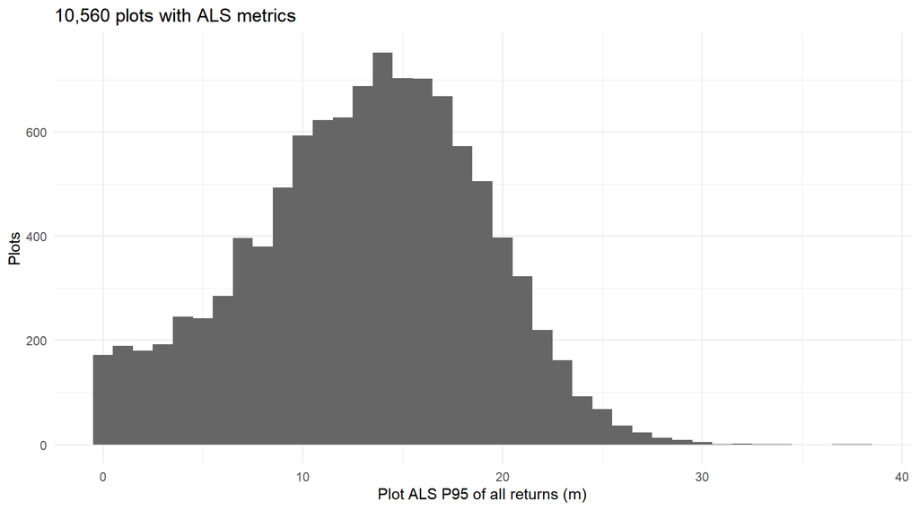

```r
ggplot(als, aes(zq95)) + geom_histogram(binwidth = 1, fill = "grey40") +
  labs(x = "Plot ALS P95 of all returns (m)", y = "Plots", title = sprintf("%s plots with ALS metrics", format(nrow(als), big.mark = ",")))
```

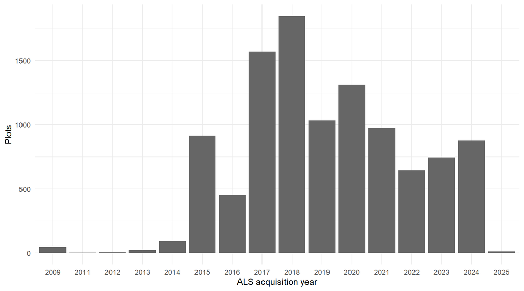

```r
ggplot(als, aes(factor(als_year))) + geom_bar(fill = "grey40") + labs(x = "ALS acquisition year", y = "Plots")
```

# Step 4. Plot buffers

```python
"""
04_make_plot_buffers.py - 150 m buffers around the PEP plots that have ALS metrics, used as the polygons of the
ICESat-2 / GEDI download (05_get_spaceborne_lidar.py, masked mode).

Author:    João Paulo Czarnecki de Liz (developer)
Co-author: Claude (Anthropic), AI coding assistant
Licence:   MIT (see LICENSE)

The comparison uses samples up to 100 m from the plot centre; the 50 m margin absorbs the 30 m pixels of the
server-side mask. Buffers are drawn in Québec Lambert (EPSG:32198, metres) and saved in lon/lat.

Input   data/plot_als_metrics.csv (provided) or data/derived/plot_als_metrics_full.csv + plot_tiles.csv (steps 1-3)
Output  data/derived/plot_buffers_150m.gpkg
Run     python -I scripts/04_make_plot_buffers.py
"""
import os
import geopandas as gpd
import pandas as pd

ROOT = os.environ.get("EXERCISE_ROOT", ".")
OUT = os.path.join(ROOT, "data", "derived"); os.makedirs(OUT, exist_ok=True)
full = os.path.join(OUT, "plot_als_metrics_full.csv")
if os.path.exists(full):          # your own extraction (steps 1-3)
    m = pd.read_csv(full)
    m = m[m.status == "ok"].merge(pd.read_csv(os.path.join(OUT, "plot_tiles.csv"))[["plot_id", "latitude", "longitude"]], on="plot_id")
else:                             # the table provided with the exercise
    m = pd.read_csv(os.path.join(ROOT, "data", "plot_als_metrics.csv"))
g = gpd.GeoDataFrame(m[["plot_id"]], geometry=gpd.points_from_xy(m.longitude, m.latitude), crs=4326)
g["geometry"] = g.to_crs(32198).buffer(150, quad_segs=8).to_crs(4326)
g.to_file(os.path.join(OUT, "plot_buffers_150m.gpkg"))
print(f"{len(g)} plot buffers -> {OUT}/plot_buffers_150m.gpkg")
```

```
10560 plot buffers -> .\data\derived/plot_buffers_150m.gpkg
```

```r
check_step(4)
```

```
Step 4
  [PASS] one buffer per plot with ALS - 10560 buffers, 10560 plots
  [PASS] buffer area = pi x 150^2 - 70233 m2 (median)
  [PASS] valid geometries
```

# Step 5. ICESat-2 and GEDI within 150 m of the plots

```python
"""
05_get_spaceborne_lidar.py - ICESat-2 ATL08 segments or GEDI L2A / L4A footprints for ANY polygons
================================================================================================

Author:    João Paulo Czarnecki de Liz (developer)
Co-author: Claude (Anthropic), AI coding assistant
Licence:   MIT (see LICENSE)

Data come from the SlideRule Earth public API (slideruleearth.io). SlideRule finds the NASA
granules that cross your area, subsets them on its own servers and streams back only the samples
inside the query polygon: no Earthdata login, no token, no HDF5 download.

Products (--product)
  atl08    ICESat-2 ATL08 land & vegetation (release 007 as of 2026-11). One row = one 100 m
           along-track segment of one beam. Global, Oct 2018 -> present.
           Key fields: h_canopy (RH98 of canopy photons, m; NaN = no canopy found), h_mean_canopy,
           h_te_median (terrain), canopy_openness, segment_snowcover, spot (1/3/5 = strong beams),
           solar_elevation, rgt/cycle/gt (track identifiers). The 18 canopy-height percentiles
           (canopy_h_metrics) are expanded to columns ch_p10 ... ch_p95.
  gedi02a  GEDI L2A elevation and relative-height (RH) metrics. One row = one ~25 m footprint.
           51.6 S - 51.6 N only; Apr 2019 - Mar 2023, then again from Apr 2024.
           Key fields: rh25 ... rh100 (m above ground; rh98 ~ canopy top), elevation_lm (ground),
           elevation_hr (highest return), sensitivity, beam (5/6/8/11 = full-power), leaf_off_flag.
  gedi04a  GEDI L4A above-ground biomass density. Same footprints as L2A. Key field: agbd (Mg/ha).

What the script does
  1. Reads any vector file, reprojects to lon/lat (EPSG:4326) and repairs invalid geometry.
  2. Builds query regions: polygons closer than 2 x --group-buffer-m are merged into a group
     (one convex hull each). A group larger than --tile-km x --tile-km is cut into tiles, and
     each tile is queried with the convex hull of the polygon part inside it. This keeps every
     request small enough to finish in seconds and to be retried on its own.
     Masked mode (--mask-cell-km > 0), for many small scattered polygons such as buffers around
     field plots: polygons are grouped into square cells of that size; each cell is queried with
     the convex hull of its polygons PLUS a raster mask of the polygons themselves (SlideRule
     'region_mask'), so the server returns only the samples inside the polygons. In a test on 12
     plot buffers this returned 23 instead of 2,961 shots and ran ~10x faster.
  3. Requests one region x year (season = --months) at a time (--workers in parallel), retries 3x
     on server errors, and caches each answer in <out>_cache/: an interrupted run resumes.
  4. Applies the server-side quality filters for GEDI (degraded shots removed; L2A or L4A
     quality flag). ICESat-2 filters (snow, beams, height) are left to the summary step
     (summarise_lidar_by_polygon.R) so you can change them without downloading again.
  5. Merges the chunks, removes duplicates, and keeps samples that fall INSIDE each original
     polygon (a sample in nested or overlapping polygons is kept once per polygon).
  6. Writes <out>.parquet and <out>.csv (R reads the csv without the arrow package).

Usage (any Python >= 3.9 with: pip install sliderule geopandas pyarrow)
  python -I scripts/05_get_spaceborne_lidar.py catchments.gpkg --id-field site --product atl08 \
         --years 2019-2025 --months 6-9 --out out/atl08.parquet
  python -I scripts/05_get_spaceborne_lidar.py study_area.shp --id-field OBJECTID --product gedi02a \
         --years 2019-2025 --tile-km 40 --out out/gedi02a.parquet
  # all 101 RH values (for waveform-style plots; large files - use on small areas only)
  python -I scripts/05_get_spaceborne_lidar.py box.gpkg --id-field id --product gedi02a --rh all --out out/rh_all.parquet
  # 10,000 plot buffers across a province: masked mode, 4 requests at a time
  python -I scripts/05_get_spaceborne_lidar.py data/derived/plot_buffers_150m.gpkg --id-field plot_id --product gedi02a \
         --mask-cell-km 100 --workers 4 --out data/derived/gedi02a_plots.parquet

Tested 2026-11-10 with sliderule 5.8.1, geopandas 1.2, Python 3.11 (Windows).
"""
import argparse, sys, time
from concurrent.futures import ThreadPoolExecutor
from pathlib import Path
import numpy as np, pandas as pd, geopandas as gpd, sliderule
from shapely.geometry import box
from sliderule import gedi

GEDI_MAX_LAT = 51.6                                 # GEDI orbit limit (ISS inclination); no data beyond
RH_STANDARD = [10, 25, 50, 75, 90, 95, 98, 100]     # GEDI RH percentiles kept by default (--rh standard)
ATL08_PCT = list(range(10, 100, 5))                 # the 18 percentiles in ATL08 canopy_h_metrics


def parse_range(s):
    """'2019-2025' -> (2019, 2025); '2021' -> (2021, 2021)."""
    a, b = (s.split("-") + [s])[:2]
    return int(a), int(b)


def query_regions(polys, buffer_m, tile_km):
    """Return a list of (name, lon/lat polygon) query regions covering all polygons.

    Neighbouring polygons share one region (fewer requests); a large region is tiled so that
    each request stays small. Each tile is queried with the convex hull of the polygon part
    inside it, so no time is spent on empty corners of the bounding box.
    """
    utm = polys.estimate_utm_crs()
    p = polys.to_crs(utm)
    merged = p.buffer(buffer_m).union_all()
    parts = list(merged.geoms) if merged.geom_type == "MultiPolygon" else [merged]
    regions, tile_m = [], tile_km * 1000
    for gi, part in enumerate(parts):
        x0, y0, x1, y1 = part.bounds
        if tile_km <= 0 or (x1 - x0 <= tile_m and y1 - y0 <= tile_m):
            regions.append((f"g{gi}", part.convex_hull))
            continue
        ti = 0
        for x in np.arange(x0, x1, tile_m):
            for y in np.arange(y0, y1, tile_m):
                piece = part.intersection(box(x, y, x + tile_m, y + tile_m))
                if piece.is_empty or piece.area < 1e4:        # skip slivers < 1 ha
                    continue
                regions.append((f"g{gi}_t{ti:03d}", piece.convex_hull)); ti += 1
    names = [r[0] for r in regions]
    geoms = gpd.GeoSeries([r[1] for r in regions], crs=utm).to_crs(4326)
    return [(n, g, None) for n, g in zip(names, geoms)]
```

```python
def masked_regions(polys, cell_km, res_m):
    """Masked mode: one region per cell_km square cell = (name, convex hull, raster mask of the polygons)."""
    utm = polys.estimate_utm_crs()
    c = polys.to_crs(utm).geometry.centroid
    key = (np.floor(c.x / (cell_km * 1000)).astype(int).astype(str) + "_" +
           np.floor(c.y / (cell_km * 1000)).astype(int).astype(str))
    out = []
    for k, g in polys.groupby(key.values):
        gdf = gpd.GeoDataFrame(geometry=g.geometry.values, crs=4326)
        hull = gdf.union_all().convex_hull.buffer(res_m / 111_320)       # pad by one mask pixel
        mask = sliderule.toregion(gdf, cellsize=res_m / 111_320)["raster"]
        out.append((f"c{k}", hull, mask))
    return out


def fetch(product, poly, t0, t1, rh_mode, mask=None):
    """One SlideRule request. Returns a GeoDataFrame (index = time)."""
    parms = {"poly": poly, "t0": t0, "t1": t1}
    if mask is not None:
        parms["region_mask"] = mask                           # only samples inside the polygons come back
    if product == "atl08":
        return sliderule.run("atl08x", parms)                 # native ATL08 fields, all beams
    # GEDI: degraded shots out + the product's own quality flag. SlideRule silently IGNORES a
    # misspelled parameter, so check the 'flags' column (bit 0 degrade, 1 L2A ok, 2 L4A ok).
    parms |= {"degrade_filter": True}
    if product == "gedi02a":
        parms |= {"l2_quality_filter": True, "anc_fields": ["rh", "land_cover_data/leaf_off_flag"]}
        return gedi.gedi02ap(parms)
    parms |= {"l4_quality_filter": True, "anc_fields": ["land_cover_data/leaf_off_flag", "agbd_se"]}
    return gedi.gedi04ap(parms)


def expand_arrays(df, product, rh_mode):
    """Turn array columns into plain numeric columns so the output is portable (csv, R)."""
    if product == "atl08" and "canopy_h_metrics" in df:
        ok = df["canopy_h_metrics"].apply(lambda a: a is not None and np.size(a) == len(ATL08_PCT))
        m = np.full((len(df), len(ATL08_PCT)), np.nan, dtype="float32")
        if ok.any():
            m[ok.to_numpy()] = np.vstack(df.loc[ok, "canopy_h_metrics"].to_numpy())
        for j, k in enumerate(ATL08_PCT):
            df[f"ch_p{k}"] = m[:, j]
        df = df.drop(columns="canopy_h_metrics")
    if product == "gedi02a" and "rh" in df:
        rh = np.vstack(df["rh"].to_numpy()).astype("float32")          # 101 values: RH0 ... RH100
        keep = range(101) if rh_mode == "all" else RH_STANDARD
        for k in keep:
            df[f"rh{k}"] = rh[:, k]
        df = df.drop(columns="rh")
    return df.rename(columns={"land_cover_data/leaf_off_flag": "leaf_off_flag"})


def main():
    ap = argparse.ArgumentParser(description=__doc__, formatter_class=argparse.RawDescriptionHelpFormatter)
    ap.add_argument("polygons", help="any vector file GeoPandas can read (gpkg, shp, geojson ...)")
    ap.add_argument("--id-field", required=True, help="column that identifies each polygon")
    ap.add_argument("--product", choices=["atl08", "gedi02a", "gedi04a"], default="atl08")
    ap.add_argument("--years", default="2019-2025", help="e.g. 2019-2025 or 2021")
    ap.add_argument("--months", default="6-9", help="season window, e.g. 6-9 (leaf-on); 1-12 for all")
    ap.add_argument("--group-buffer-m", type=float, default=250,
                    help="polygons closer than 2x this are queried together (default 250 m)")
    ap.add_argument("--tile-km", type=float, default=40,
                    help="query regions larger than this (km) are tiled; 0 = never tile (default 40)")
    ap.add_argument("--rh", choices=["standard", "all"], default="standard",
                    help="GEDI L2A: keep RH10/25/50/75/90/95/98/100 (standard) or all 101 values")
    ap.add_argument("--mask-cell-km", type=float, default=0,
                    help="masked mode for many small scattered polygons: group them in cells of this size and "
                         "let the server return only samples inside the polygons (e.g. 100; default 0 = off)")
    ap.add_argument("--mask-res-m", type=float, default=30,
                    help="mask pixel size in m (masked mode); keep it well below the polygon size (default 30)")
    ap.add_argument("--workers", type=int, default=1, help="requests sent in parallel (default 1; 4 is polite)")
    ap.add_argument("--out", required=True, help="output .parquet (a .csv copy is written too)")
    a = ap.parse_args()

    # 1. polygons ------------------------------------------------------------------------
    polys = gpd.read_file(a.polygons)[[a.id_field, "geometry"]].to_crs(4326)
    polys["geometry"] = polys.make_valid()
    if a.product.startswith("gedi"):
        b = polys.geometry.bounds
        off = (b.miny > GEDI_MAX_LAT) | (b.maxy < -GEDI_MAX_LAT)
        if off.any():
            print(f"! {off.sum()} polygon(s) lie entirely beyond {GEDI_MAX_LAT} deg - GEDI has no data there; skipped:",
                  ", ".join(map(str, polys.loc[off, a.id_field])), flush=True)
            polys = polys[~off]
        if polys.empty:
            sys.exit("No polygon inside GEDI coverage - use --product atl08.")

    # 2. query regions -------------------------------------------------------------------
    y0, y1 = parse_range(a.years); m0, m1 = parse_range(a.months)
    out = Path(a.out); cache = out.with_name(out.stem + "_cache"); cache.mkdir(parents=True, exist_ok=True)
    if a.mask_cell_km > 0:
        regions = masked_regions(polys, a.mask_cell_km, a.mask_res_m)
    else:
        regions = query_regions(polys, a.group_buffer_m, a.tile_km)
    print(f"{len(polys)} polygon(s) -> {len(regions)} query region(s){' (masked)' if a.mask_cell_km > 0 else ''}; "
          f"{a.product}; {y0}-{y1}, months {m0}-{m1}", flush=True)
    gpd.GeoDataFrame({"region": [r[0] for r in regions]}, geometry=[r[1] for r in regions], crs=4326) \
       .to_file(cache / "query_regions.gpkg")                    # handy to map what was requested

    # 3-4. requests, one region x year at a time, cached ----------------------------------
    sliderule.init("slideruleearth.io", verbose=False)
```

```python
    def one_chunk(task):
        name, geom, mask, y = task
        f = cache / f"{name}_{y}.parquet"
        if f.exists():
            return
        poly = sliderule.toregion(gpd.GeoDataFrame(geometry=[geom], crs=4326))["poly"]
        t0 = f"{y}-{m0:02d}-01T00:00:00Z"
        t1 = (pd.Timestamp(year=y, month=m1, day=1) + pd.offsets.MonthEnd(0)).strftime("%Y-%m-%dT23:59:59Z")
        df = None
        for attempt in range(3):
            try:
                t = time.time(); df = fetch(a.product, poly, t0, t1, a.rh, mask); break
            except Exception as e:                                           # busy server / timeout
                print(f"  {name} {y}: attempt {attempt + 1} failed ({e!r:.150})", flush=True); time.sleep(30)
        if df is None:
            print(f"  {name} {y}: giving up (rerun later; finished chunks are cached)", flush=True); return
        if len(df) == 0:
            df = gpd.GeoDataFrame({"empty": []}, geometry=[], crs=4326)
        else:
            df = expand_arrays(df.reset_index(), a.product, a.rh)           # time index -> column
        df.to_parquet(f)
        print(f"  {name} {y}: {len(df):7d} samples ({time.time() - t:.0f} s)", flush=True)

    tasks = [(n, g, m, y) for n, g, m in regions for y in range(y0, y1 + 1)]
    if a.workers > 1:
        with ThreadPoolExecutor(a.workers) as ex:
            list(ex.map(one_chunk, tasks))
    else:
        for task in tasks:
            one_chunk(task)

    # 5. merge, de-duplicate, clip to the original polygons --------------------------------
    parts = [gpd.read_parquet(f) for f in sorted(cache.glob("*_*.parquet"))]
    parts = [p.drop(columns=["empty"], errors="ignore") for p in parts if len(p)]
    if not parts:
        sys.exit("No samples returned for these polygons and dates.")
    seg = gpd.GeoDataFrame(pd.concat(parts, ignore_index=True), geometry="geometry")
    seg = seg.set_crs(4326, allow_override=True)       # SlideRule returns ITRF (EPSG:9989/7912); lon/lat = WGS84 to cm
    seg = seg.drop(columns=["index", "level_0"], errors="ignore")
    keys = ["time_ns", "rgt", "cycle", "gt", "segment_id_beg"] if a.product == "atl08" else ["time", "beam"]
    seg = seg.drop_duplicates(subset=[k for k in keys if k in seg])
    joined = gpd.sjoin(seg, polys, predicate="within", how="inner").drop(columns="index_right")
    joined["lon"] = joined.geometry.x; joined["lat"] = joined.geometry.y
    joined = pd.DataFrame(joined.drop(columns="geometry"))

    # 6. write -----------------------------------------------------------------------------
    joined.to_parquet(out); joined.to_csv(out.with_suffix(".csv"), index=False)
    tcol = "time_ns" if a.product == "atl08" else "time"
    yrs = pd.to_datetime(joined[tcol]).dt.year.value_counts().sort_index()
    print(f"\n{len(seg)} unique samples in the query regions; {len(joined)} sample x polygon rows -> {out}")
    print("samples per year:", yrs.to_dict())
    n = joined.groupby(a.id_field).size()
    if len(n) <= 50:
        print(n.rename("n").to_string())
    else:
        print(f"{len(n)} of {len(polys)} polygons have samples; per polygon: median {n.median():.0f}, max {n.max()}")


if __name__ == "__main__":
    main()
```

```r
check_step(5)
```

```
Step 5
  [PASS] gedi02a columns
  [PASS] gedi02a plot_id all in the ALS table - 51,959 rows, 7,620 plots
  [PASS] gedi02a years 2019-2025 - 2019-2025
  [PASS] gedi02a months June-September - 0.2% outside (granules selected by date)
  [PASS] gedi02a no duplicated sample x plot
  [PASS] GEDI south of 51.6 N - max lat 51.60
  [PASS] GEDI server filters applied (flags: bit 0 off, bit 1 on)
  [PASS] GEDI RH95 within -5..60 m - 0.15% outside
  [PASS] atl08 columns
  [PASS] atl08 plot_id all in the ALS table - 13,686 rows, 3,407 plots
  [PASS] atl08 years 2019-2025 - 2019-2025
  [PASS] atl08 months June-September - 0.0% outside (granules selected by date)
  [PASS] atl08 no duplicated sample x plot
  [PASS] ATL08 h_canopy within 0..60 m (or NA = no canopy)
```

```r
sat <- function(p) { f <- file.path("data/derived", paste0(p, "_plots.csv")); if (!file.exists(f)) f <- file.path("data/satellite", paste0(p, "_plots.csv")); fread(f) }
g <- sat("gedi02a"); a <- sat("atl08")
rbind(data.table(sensor = "GEDI L2A", year = as.integer(substr(g$time, 1, 4))),
      data.table(sensor = "ICESat-2 ATL08", year = as.integer(substr(a$time_ns, 1, 4))))[, .N, by = .(sensor, year)] |>
  dcast(year ~ sensor, value.var = "N")
```

| year | GEDI L2A | ICESat-2 ATL08 |
| --- | --- | --- |
| 2019 | 9692 | 2193 |
| 2020 | 10410 | 2400 |
| 2021 | 7978 | 1879 |
| 2022 | 9628 | 2045 |
| 2023 | NA | 1702 |
| 2024 | 11633 | 1607 |
| 2025 | 2618 | 1860 |

# Step 6. Disturbance records under the plots

```python
"""
06_query_mrnf_events.py - forest interventions, fires and other disturbances recorded by the MRNF under each plot

Author:    João Paulo Czarnecki de Liz (developer)
Co-author: Claude (Anthropic), AI coding assistant
Licence:   MIT (see LICENSE)

Queries the public MRNF web feature service (WFS) for the polygons of three layers that intersect the 11.28 m
plot circle, and keeps the share of the circle each polygon covers:
  ca_interv_for_close_scale     harvests (ORIGINE: clearcut, CPRS, ...) and partial cuts / tending (PERTURB)
  ca_feu_close_scale            fires
  ca_perturb_autre_close_scale  windthrow, insect outbreaks, dieback, ice storm, ...
A pair (plot, satellite sample) is later discarded when one of these events falls between the ALS flight and the
satellite date. One JSON per plot is cached, so the ~10,000 queries resume after an interruption.

Input   data/plot_als_metrics.csv (or data/derived/plot_tiles.csv)
Output  data/derived/plot_mrnf_events.csv   (plot_id, layer, exercice, origine, an_origine, perturb, an_perturb, overlap)
Run     python -I scripts/06_query_mrnf_events.py        (~1 h with 6 parallel requests; WORKERS=6 by default)
"""
import json
import math
import os
import time
import urllib.parse
import urllib.request
from concurrent.futures import ThreadPoolExecutor

import pandas as pd
from shapely import affinity
from shapely.geometry import Point, shape

ROOT = os.environ.get("EXERCISE_ROOT", ".")
OUT = os.path.join(ROOT, "data", "derived"); CACHE = os.path.join(OUT, "mrnf_cache")
os.makedirs(CACHE, exist_ok=True)
WFS = "https://geoegl.msp.gouv.qc.ca/ws/mffpecofor.fcgi"
LAYERS = ["ca_interv_for_close_scale", "ca_feu_close_scale", "ca_perturb_autre_close_scale"]
FIELDS = ["exercice", "origine", "an_origine", "perturb", "an_perturb", "classe", "origine_desc", "perturb_desc"]
PLOT_RADIUS_M = 11.28
WORKERS = int(os.environ.get("WORKERS", "6"))


def plot_circle(lon, lat):
    """11.28 m circle in lon/lat degrees (an ellipse in degrees, a circle on the ground)."""
    r = PLOT_RADIUS_M / 111_320
    return affinity.scale(Point(lon, lat).buffer(r, 32), xfact=1 / math.cos(math.radians(lat)), yfact=1)


def get_json(params):
    url = f"{WFS}?{urllib.parse.urlencode(params)}"
    for attempt in range(4):
        try:
            with urllib.request.urlopen(url, timeout=120) as r:
                return json.loads(r.read().decode("utf-8"))
        except Exception:  # noqa: BLE001 - busy server or bad gateway: wait and retry
            time.sleep(5 * (attempt + 1))
    raise RuntimeError(f"no answer from the WFS for {params.get('typeNames')}")


def query_plot(pid, lon, lat):
    path = os.path.join(CACHE, f"{pid}.json")
    if os.path.exists(path):
        with open(path, encoding="utf-8") as fh:
            return json.load(fh)
    circle = plot_circle(lon, lat)
    minx, miny, maxx, maxy = circle.bounds
    events = []
    for layer in LAYERS:
        js = get_json({"service": "WFS", "version": "2.0.0", "request": "GetFeature", "typeNames": f"ms:{layer}",
                       "outputFormat": "geojson", "bbox": f"{miny},{minx},{maxy},{maxx},urn:ogc:def:crs:EPSG::4326"})
        for f in js.get("features", []):
            geom = shape(f["geometry"])
            if not geom.is_valid:
                geom = geom.buffer(0)
            ov = geom.intersection(circle).area / circle.area
            if ov > 0:
                events.append({"layer": layer, **{k: f["properties"].get(k) for k in FIELDS}, "overlap": round(ov, 3)})
    out = {"plot_id": int(pid), "events": events}
    with open(path, "w", encoding="utf-8") as fh:
        json.dump(out, fh)
    return out


def main():
    src = os.path.join(ROOT, "data", "plot_als_metrics.csv")
    if not os.path.exists(src):
        src = os.path.join(OUT, "plot_tiles.csv")
    plots = pd.read_csv(src)[["plot_id", "longitude", "latitude"]].dropna()
    print(f"{len(plots)} plots; {len(os.listdir(CACHE))} already cached", flush=True)
    t0 = time.time()
    with ThreadPoolExecutor(WORKERS) as ex:
        res = list(ex.map(lambda r: query_plot(int(r.plot_id), r.longitude, r.latitude), plots.itertuples()))
    rows = [{"plot_id": r["plot_id"], **e} for r in res for e in r["events"]]
    ev = pd.DataFrame(rows, columns=["plot_id", "layer"] + FIELDS + ["overlap"])
    ev.to_csv(os.path.join(OUT, "plot_mrnf_events.csv"), index=False)
    print(f"{len(ev)} events on {ev.plot_id.nunique()} plots ({(time.time() - t0) / 60:.0f} min) -> {OUT}/plot_mrnf_events.csv")


if __name__ == "__main__":
    main()
```

```r
check_step(6)
```

```
Step 6
  using ./data/plot_mrnf_events.csv
  [PASS] event columns
  [PASS] overlap in [0, 1] - 15 slivers round to 0; step 7 keeps events covering >= 50% of the plot
  [PASS] plot_id all in the ALS table - 10,007 events on 6,359 plots
  [PASS] known layers
```

```r
ev <- fread(if (file.exists("data/derived/plot_mrnf_events.csv")) "data/derived/plot_mrnf_events.csv" else "data/plot_mrnf_events.csv")
ev[, year := fcoalesce(as.numeric(an_perturb), as.numeric(an_origine), as.numeric(exercice))]
ev[year >= 2010 & overlap >= 0.5, .N, by = .(layer, period = cut(year, c(2009, 2014, 2019, 2026), labels = c("2010-2014", "2015-2019", "2020-2025")))] |>
  dcast(layer ~ period, value.var = "N", fill = 0)
```

| layer | 2010-2014 | 2015-2019 | 2020-2025 |
| --- | --- | --- | --- |
| ca_feu_close_scale | 60 | 4 | 171 |
| ca_interv_for_close_scale | 513 | 492 | 376 |
| ca_perturb_autre_close_scale | 17 | 58 | 213 |

# Step 7. Plot table: forest type, domain, events since 2010

```python
"""
07_build_plot_table.py - one row per PEP plot with ALS metrics, ready to be paired with ICESat-2 and GEDI

Author:    João Paulo Czarnecki de Liz (developer)
Co-author: Claude (Anthropic), AI coding assistant
Licence:   MIT (see LICENSE)

Adds to the ALS metrics:
  * the ALS acquisition date and month (first date when a tile was flown on several days);
  * the bioclimatic domain (PEP table classi_eco_pe);
  * the forest type, from the live trees (dbh >= 9.1 cm) of the PEP measurement closest to the ALS date:
    softwood >= 75 % of the live basal area, hardwood >= 75 %, mixed otherwise, "Open / regenerating" when
    the live basal area is below 4 m2/ha;
  * the MRNF events from 2010 on that cover at least half of the plot, with their year, so that the comparison
    can drop a plot-satellite pair when an event falls between the two dates.

Input   data/raw/PEP.gpkg; data/plot_als_metrics.csv (or data/derived/plot_als_metrics_full.csv + plot_tiles.csv);
        data/plot_mrnf_events.csv (or data/derived/plot_mrnf_events.csv from step 6)
Output  data/derived/plots_province.csv, data/derived/plot_events_2010plus.csv
Run     python -I scripts/07_build_plot_table.py          (~2 min)
"""
import os
import sqlite3
import numpy as np
import pandas as pd

ROOT = os.environ.get("EXERCISE_ROOT", ".")
D, OUT = os.path.join(ROOT, "data"), os.path.join(ROOT, "data", "derived")
os.makedirs(OUT, exist_ok=True)
PEP = os.environ.get("PEP_GPKG", os.path.join(D, "raw", "PEP.gpkg"))
SOFTWOOD = {"SAB", "EPN", "EPB", "EPR", "EPO", "PIG", "PIB", "PIR", "PIS", "PRU", "THO", "MEL", "MEH", "MEJ", "MEU"}
LIVE = {"10", "12", "30", "32", "40", "42", "50", "52"}          # PEP tree-status codes of live trees
ALS = ["pt_density_m2", "zq50", "zq95", "zmax"]

# ALS metrics: your own extraction if it exists, else the table provided with the exercise
full = os.path.join(OUT, "plot_als_metrics_full.csv")
if os.path.exists(full):
    m = pd.read_csv(full); m = m[m.status == "ok"][["plot_id"] + ALS]
    p = pd.read_csv(os.path.join(OUT, "plot_tiles.csv"))[["plot_id", "latitude", "longitude", "DATES_ACQUISITION",
                                                         "CAPTEUR", "DENSITE"]].merge(m, on="plot_id")
else:
    p = pd.read_csv(os.path.join(D, "plot_als_metrics.csv"))
p["als_date"] = pd.to_datetime(p.DATES_ACQUISITION.str.split(",").str[0])
p["als_year"], p["als_month"] = p.als_date.dt.year, p.als_date.dt.month
p["id_pe"] = p.plot_id.astype(np.int64).astype(str).str.zfill(10)

con = sqlite3.connect(PEP)
eco = pd.read_sql("select id_pe, dom_bio, sdom_bio from classi_eco_pe", con)
mes = pd.read_sql("select id_pe, id_pe_mes, no_mes, date_sond from placette_mes", con)
mes = mes[mes.id_pe.isin(p.id_pe)].merge(p[["id_pe", "als_date"]], on="id_pe")
mes["field_date"] = pd.to_datetime(mes.date_sond.str[:10], errors="coerce")
mes["d"] = (mes.field_date - mes.als_date).abs()
pick = mes.sort_values("d").groupby("id_pe").head(1)                 # measurement closest to the ALS flight
tr = pd.read_sql("select id_pe_mes, etat, essence, st_ha from dendro_arbres", con)
tr = tr[tr.id_pe_mes.isin(pick.id_pe_mes) & tr.etat.isin(LIVE)]
tr["soft"] = tr.essence.isin(SOFTWOOD)
ba = tr.groupby("id_pe_mes").agg(ba_live=("st_ha", "sum"))
ba["soft_share"] = tr[tr.soft].groupby("id_pe_mes").st_ha.sum().reindex(ba.index).fillna(0) / ba.ba_live
pick = pick.merge(ba, left_on="id_pe_mes", right_index=True, how="left")
pick["forest_type"] = np.select([pick.ba_live.isna() | (pick.ba_live < 4), pick.soft_share >= 0.75, pick.soft_share <= 0.25],
                                ["Open / regenerating", "Softwood", "Hardwood"], "Mixed")
pick["field_year"] = pick.field_date.dt.year
p = p.merge(pick[["id_pe", "field_year", "ba_live", "soft_share", "forest_type"]], on="id_pe", how="left") \
     .merge(eco, on="id_pe", how="left")

evf = os.path.join(OUT, "plot_mrnf_events.csv")
ev = pd.read_csv(evf if os.path.exists(evf) else os.path.join(D, "plot_mrnf_events.csv"))
ev = ev[ev.plot_id.isin(p.plot_id) & (ev.overlap >= 0.5)].copy()
ev["year"] = ev.an_perturb.fillna(ev.an_origine).fillna(ev.exercice)        # year of the event, else of the record
ev = ev[ev.year >= 2010]
ev["kind"] = np.where(ev.layer == "ca_feu_close_scale", "fire",
                      np.where(ev.layer == "ca_interv_for_close_scale",
                               np.where(ev.origine.notna(), "harvest", "partial cut / tending"), "other natural"))
ev[["plot_id", "year", "kind", "origine", "perturb"]].to_csv(os.path.join(OUT, "plot_events_2010plus.csv"), index=False)
p.drop(columns=["id_pe"]).to_csv(os.path.join(OUT, "plots_province.csv"), index=False)
print(f"{len(p)} plots; forest types {p.forest_type.value_counts().to_dict()}")
print("ALS years:", p.als_year.value_counts().sort_index().to_dict())
print(f"{ev.plot_id.nunique()} plots with an MRNF event since 2010 ({len(ev)} events)")
```

```
10560 plots; forest types {'Softwood': 4106, 'Mixed': 2535, 'Hardwood': 2266, 'Open / regenerating': 1652}
ALS years: {2009: 49, 2011: 3, 2012: 6, 2013: 24, 2014: 91, 2015: 915, 2016: 453, 2017: 1571, 2018: 1847, 2019: 1035, 2020: 1310, 2021: 974, 2022: 645, 2023: 746, 2024: 878, 2025: 13}
1476 plots with an MRNF event since 2010 (1904 events)
```

```r
check_step(7)
```

```
Step 7
  [PASS] one row per plot with ALS - 10,560 rows
  [PASS] forest type assigned - 100.0%
  forest types:  1; Hardwood 2266; Mixed 2535; Open / regenerating 1652; Softwood 4106
  [PASS] ALS dates 2009-2025 - 2009-2025
  [PASS] field measurement near the ALS - median 2 years apart
  [PASS] events since 2010 - 1,476 plots
```

```r
pp <- fread("data/derived/plots_province.csv")
pp[, als_season := fifelse(als_month %in% 6:9, "leaf-on ALS", "leaf-off / transition ALS")]
dcast(pp[, .N, by = .(forest_type, als_season)], forest_type ~ als_season, value.var = "N")
```

| forest_type | leaf-off / transition ALS | leaf-on ALS |
| --- | --- | --- |
|  | NA | 1 |
| Hardwood | 962 | 1304 |
| Mixed | 816 | 1719 |
| Open / regenerating | 286 | 1366 |
| Softwood | 669 | 3437 |

# Step 8. Pairs, statistics and figures

```r
###############################################################################
# 08_compare_figures.R - ICESat-2 and GEDI against the ALS metrics of the Québec PEP plots (province-wide)
#
# Author:    João Paulo Czarnecki de Liz (developer)
# Co-author: Claude (Anthropic), AI coding assistant
# Licence:   MIT (see LICENSE)
#
# A pair = one satellite sample within 100 m of one plot centre, after the default quality filters (GEDI
# leaf-on flag and sensitivity >= 0.95; ATL08 strong beams, snow-free), June-September 2019-2025.
# Compared metrics (plot ALS from data/plot_als_metrics.csv, 11.28 m plots):
#   GEDI RH95        <-> plot P95 of all returns (zq95)   same definition
#   GEDI RH50        <-> plot P50 (zq50)                  same definition
#   ATL08 h_canopy   <-> plot P95 (zq95)                  close, not identical (P98 of canopy photons over 100 m)
# "On the plot": a GEDI footprint overlapping the plot (centre <= 25 m); an ICESat-2 segment crossing it
# (tracks run nearly north-south here: |east offset| <= 18 m and |north offset| <= 61 m).
# Delay = satellite date - ALS date (years; negative when the satellite came first). A pair is "disturbed" when
# an MRNF harvest, partial cut, fire or other event falls between the ALS year and the satellite year.
# 95% intervals: bootstrap over plots (the pairs of one plot share its ALS and its ground).
#
# Run    Rscript scripts/08_compare_figures.R          (~5 min)
# Inputs data/derived/plots_province.csv, plot_events_2010plus.csv (step 7);
#        data/derived/gedi02a_plots.csv, atl08_plots.csv (step 5) or the copies provided in data/satellite/
# Output docs/assets/img/P1-P4_*.png (the figures of the site), outputs/*.csv, outputs/numbers.txt
###############################################################################
suppressPackageStartupMessages({ library(sf); library(ggplot2); library(patchwork); library(data.table); library(scales) })
sf_use_s2(FALSE); invisible(Sys.setlocale("LC_TIME", "C"))
ROOT <- Sys.getenv("EXERCISE_ROOT", ".")
DAT  <- file.path(ROOT, "data/derived")
FIG  <- Sys.getenv("FIG_DIR", file.path(ROOT, "docs/assets/img")); OUTP <- Sys.getenv("OUT_DIR", file.path(ROOT, "outputs"))
dir.create(FIG, showWarnings = FALSE, recursive = TRUE); dir.create(OUTP, showWarnings = FALSE, recursive = TRUE)
sat_file <- function(f) { p <- file.path(DAT, f); if (file.exists(p)) p else file.path(ROOT, "data/satellite", f) }
# (the helpers of that file are defined in the 'Helpers' chunks at the top)
set.seed(1)
NUM <- file.path(OUTP, "numbers.txt"); cat("", file = NUM)
say <- function(...) { s <- sprintf(...); cat(s, "\n"); cat(s, "\n", file = NUM, append = TRUE) }

# --- look -----------------------------------------------------------------------------------
SENSOR <- c("GEDI L2A" = "#eb6834", "ICESat-2 ATL08" = "#2a78d6")
FT_PAL <- c("Softwood" = "#1f7a4d", "Mixed" = "#7d55d0", "Hardwood" = "#c47a00", "Open / regenerating" = "#8e8e8e")
LEAF_ON  <- "Leaf-on ALS (June–September)"
LEAF_OFF <- "Leaf-off or transition ALS (April–May, October–December)"
SEASON_PAL <- setNames(c("#5b8c00", "#c2479a"), c(LEAF_ON, LEAF_OFF))
EV_PAL <- c("No MRNF event" = "#333333", "Harvest, cut or fire in between" = "#c2479a")
INK2 <- "grey35"
theme_set(theme_minimal(base_size = 10) +
            theme(panel.grid.minor = element_blank(), plot.title = element_text(face = "bold", size = 12),
                  plot.title.position = "plot", plot.subtitle = element_text(colour = INK2),
                  strip.text = element_text(face = "bold"), panel.border = element_rect(fill = NA, colour = "grey88")))
save <- function(p, f, w, h) { ggsave(file.path(FIG, f), p, width = w, height = h, dpi = 200, bg = "white"); cat("  wrote", f, "\n") }
fmt  <- function(x, d = 0) formatC(x, format = "f", digits = d, big.mark = ",")
rmse <- function(x) sqrt(mean(x^2))
st   <- function(s, a) { d <- s - a; data.table(n = length(d), r = cor(s, a), bias = mean(d), rmse = rmse(d), mae = mean(abs(d))) }
lab  <- function(x) sprintf("n = %s pairs (%s plots)\nr = %.2f\nbias = %+.1f m\nRMSE = %.1f m", fmt(x$n), fmt(x$plots), x$r, x$bias, x$rmse)
boot_plot <- function(d, fun, B = 300) {                 # 95% interval, resampling whole plots
  if (!nrow(d)) return(c(NA_real_, NA_real_))
  idx <- split(seq_len(nrow(d)), d$plot_id)
  v <- replicate(B, fun(d[unlist(idx[sample(length(idx), replace = TRUE)], use.names = FALSE)]))
  as.numeric(quantile(v, c(0.025, 0.975), na.rm = TRUE))
}

# --- data -----------------------------------------------------------------------------------
P <- fread(file.path(DAT, "plots_province.csv"))
P[, als_date := as.Date(als_date)]
P[, als_season := factor(fifelse(als_month %in% 6:9, LEAF_ON, LEAF_OFF), levels = c(LEAF_ON, LEAF_OFF))]
P[, forest_type := factor(forest_type, levels = names(FT_PAL))]
EV <- fread(file.path(DAT, "plot_events_2010plus.csv"))
pxy <- st_coordinates(st_transform(st_as_sf(P, coords = c("longitude", "latitude"), crs = 4326), 32198))
P[, `:=`(px = pxy[, 1], py = pxy[, 2])]

prep <- function(file, product, sensor) {
  d <- as.data.table(lidar_filter(read_lidar(file), product))
  xy <- st_coordinates(st_transform(st_as_sf(d[, .(lon, lat)], coords = c("lon", "lat"), crs = 4326), 32198))
  d[, `:=`(sx = xy[, 1], sy = xy[, 2], sat_date = as.Date(substr(as.character(time), 1, 10)), sensor = sensor)]
  d <- merge(d, P[, .(plot_id, px, py, plon = longitude, plat = latitude, als_date, als_year, als_season, forest_type,
                      dom_bio, zq95, zq50, zmax)], by = "plot_id")
  d[, `:=`(dist = sqrt((sx - px)^2 + (sy - py)^2), gap = as.numeric(sat_date - als_date) / 365.25,
           dE = (lon - plon) * cos(plat * pi / 180) * 111320, dN = (lat - plat) * 110574)]
  d <- d[dist <= 100 & month(sat_date) %in% 6:9]
  d[, on_plot := if (product == "atl08") abs(dE) <= 18 & abs(dN) <= 61 else dist <= 25]
  e <- merge(d[, .(row = .I, plot_id, y0 = pmin(als_year, year(sat_date)), y1 = pmax(als_year, year(sat_date)))], EV,
             by = "plot_id", allow.cartesian = TRUE)[year >= y0 & year <= y1]
  d[, event := "No MRNF event"]; d[unique(e$row), event := "Harvest, cut or fire in between"]
  d
}
G <- prep(sat_file("gedi02a_plots.csv"), "gedi02a", "GEDI L2A")
A <- prep(sat_file("atl08_plots.csv"), "atl08", "ICESat-2 ATL08")
G[, `:=`(sat = rh95, als = zq95)]; A[, `:=`(sat = h, als = zq95)]
fwrite(G[, .(plot_id, time, beam, dist, on_plot, gap, event, rh95, rh50, rh98, zq95, zq50, sensitivity, forest_type, als_season)],
       file.path(OUTP, "pairs_gedi.csv"))
fwrite(A[, .(plot_id, time_ns, spot, dist, dE, dN, on_plot, gap, event, h, zq95, forest_type, als_season)], file.path(OUTP, "pairs_atl08.csv"))
say("Plots with ALS metrics: %s (south of 51.6N: %s)", fmt(nrow(P)), fmt(sum(P$latitude < 51.6)))
```

```
Plots with ALS metrics: 10,560 (south of 51.6N: 10,457)
```

```r
say("Pairs within 100 m after filters: GEDI %s (%s plots), ATL08 %s (%s plots)",
    fmt(nrow(G)), fmt(uniqueN(G$plot_id)), fmt(nrow(A)), fmt(uniqueN(A$plot_id)))
```

```
Pairs within 100 m after filters: GEDI 13,732 (4,333 plots), ATL08 3,895 (1,964 plots)
```

```r
###############################################################################
# P1 How many plots have a satellite sample nearby
###############################################################################
cat("figure P1\n")
```

```
figure P1
```

```r
cnt <- rbindlist(lapply(c(12.5, 25, 50, 100), function(r) rbind(
  data.table(sensor = "GEDI L2A", r = r, plots = uniqueN(G[dist <= r]$plot_id), pairs = nrow(G[dist <= r])),
  data.table(sensor = "ICESat-2 ATL08", r = r, plots = uniqueN(A[dist <= r]$plot_id), pairs = nrow(A[dist <= r])))))
fwrite(cnt, file.path(OUTP, "table_plots_with_samples.csv"))
for (i in seq_len(nrow(cnt))) with(cnt[i], say("%s within %.1f m: %s plots, %s pairs", sensor, r, fmt(plots), fmt(pairs)))
```

```
GEDI L2A within 12.5 m: 228 plots, 232 pairs
ICESat-2 ATL08 within 12.5 m: 54 plots, 54 pairs
GEDI L2A within 25.0 m: 867 plots, 923 pairs
ICESat-2 ATL08 within 25.0 m: 231 plots, 244 pairs
GEDI L2A within 50.0 m: 2,235 plots, 3,558 pairs
ICESat-2 ATL08 within 50.0 m: 856 plots, 967 pairs
GEDI L2A within 100.0 m: 4,333 plots, 13,732 pairs
ICESat-2 ATL08 within 100.0 m: 1,964 plots, 3,895 pairs
```

```r
onG <- unique(G[on_plot == TRUE]$plot_id); onA <- unique(A[on_plot == TRUE]$plot_id)
say("Plots with a sample ON the plot: GEDI %s (%s pairs), ICESat-2 %s (%s pairs), both %s",
    fmt(length(onG)), fmt(sum(G$on_plot)), fmt(length(onA)), fmt(sum(A$on_plot)), fmt(length(intersect(onG, onA))))
```

```
Plots with a sample ON the plot: GEDI 867 (923 pairs), ICESat-2 430 (538 pairs), both 35
```

```r
qc <- rnaturalearth::ne_states(country = "Canada", returnclass = "sf")
qc <- qc[qc$name %in% c("Québec", "Quebec"), ]
P[, near := factor(fifelse(plot_id %in% onG & plot_id %in% onA, "Both",
                    fifelse(plot_id %in% onG, "GEDI only", fifelse(plot_id %in% onA, "ICESat-2 only", "Neither"))),
                   levels = c("Neither", "ICESat-2 only", "GEDI only", "Both"))]
NEAR_PAL <- c("Neither" = "grey80", "ICESat-2 only" = SENSOR[[2]], "GEDI only" = SENSOR[[1]], "Both" = "black")
p1a <- ggplot() + geom_sf(data = qc, fill = "grey97", colour = "grey60", linewidth = 0.3) +
  geom_point(data = P[order(near)], aes(longitude, latitude, colour = near), size = 0.4, shape = 16) +
  geom_hline(yintercept = 51.6, colour = SENSOR[[1]], linetype = "22", linewidth = 0.4) +
  annotate("text", x = -79.6, y = 51.85, label = "GEDI stops at 51.6°N", hjust = 0, size = 2.7, colour = "grey20") +
  scale_colour_manual(values = NEAR_PAL, name = "Sample on the plot:") +
  guides(colour = guide_legend(override.aes = list(size = 2.5))) +
  coord_sf(xlim = c(-80, -57), ylim = c(44.8, 53), crs = 4326) +
  theme(axis.title = element_blank(), legend.position = "bottom") +
  labs(title = "a  Plots with a satellite sample on top of them",
       subtitle = sprintf("%s PEP plots with ALS metrics. Satellites: June–September 2019–2025, default filters.\nGEDI footprint overlapping the plot; ICESat-2 segment crossing it.", fmt(nrow(P))))
cnt[, sensor := factor(sensor, levels = names(SENSOR))]
p1b <- ggplot(cnt, aes(factor(r), plots, fill = sensor)) + geom_col(position = position_dodge(0.75), width = 0.7) +
  geom_text(aes(label = fmt(plots)), position = position_dodge(0.75), vjust = -0.4, size = 2.8, colour = "grey15") +
  scale_fill_manual(values = SENSOR, name = NULL) + scale_y_continuous(labels = comma, expand = expansion(mult = c(0, 0.1))) +
  labs(x = "Distance from the plot centre (m)", y = "Plots with at least one sample", title = "b  How many plots, by distance",
       subtitle = "Plot radius 11.28 m; GEDI footprint radius 12.5 m") +
  theme(legend.position = "bottom", panel.grid.major.x = element_blank())
save((p1a | p1b) + plot_layout(widths = c(1.5, 1)), "P1_plots_with_samples.png", 12.5, 6.2)
```

```
  wrote P1_plots_with_samples.png
```

```r
###############################################################################
# P2 Agreement on the plot, and how it degrades with distance
###############################################################################
cat("figure P2\n")
```

```
figure P2
```

```r
NEAR_GAP <- 2                                                       # |delay| <= 2 years
core <- function(d) d[on_plot == TRUE & abs(gap) <= NEAR_GAP & event == "No MRNF event"]
Gc <- core(G); Ac <- core(A)
sG <- cbind(st(Gc$sat, Gc$als), plots = uniqueN(Gc$plot_id)); sA <- cbind(st(Ac$sat, Ac$als), plots = uniqueN(Ac$plot_id))
sG50 <- cbind(st(Gc$rh50, Gc$zq50), plots = uniqueN(Gc$plot_id))
say("On the plot, |delay| <= %d y, no event. GEDI RH95 vs zq95: %s plots, n=%d, r=%.2f, bias=%+.2f, RMSE=%.2f, MAE=%.2f | RH50 vs zq50: r=%.2f, bias=%+.2f, RMSE=%.2f",
    NEAR_GAP, fmt(sG$plots), sG$n, sG$r, sG$bias, sG$rmse, sG$mae, sG50$r, sG50$bias, sG50$rmse)
```

```
On the plot, |delay| <= 2 y, no event. GEDI RH95 vs zq95: 339 plots, n=351, r=0.77, bias=-0.32, RMSE=4.09, MAE=2.82 | RH50 vs zq50: r=0.59, bias=+0.28, RMSE=4.66
```

```r
say("On the plot, |delay| <= %d y, no event. ATL08 h_canopy vs zq95: %s plots, n=%d, r=%.2f, bias=%+.2f, RMSE=%.2f, MAE=%.2f",
    NEAR_GAP, fmt(sA$plots), sA$n, sA$r, sA$bias, sA$rmse, sA$mae)
```

```
On the plot, |delay| <= 2 y, no event. ATL08 h_canopy vs zq95: 135 plots, n=160, r=0.62, bias=+3.29, RMSE=5.94, MAE=4.28
```

```r
for (q in list(list("GEDI", Gc), list("ATL08", Ac))) {
  x <- q[[2]][, .(e = sat - als)]
  say("  %s error quantiles (5, 25, 50, 75, 95%%): %s; share |error| > 5 m: %.0f%%", q[[1]],
      paste(sprintf("%+.1f", quantile(x$e, c(.05, .25, .5, .75, .95))), collapse = ", "), 100 * mean(abs(x$e) > 5))
}
```

```
  GEDI error quantiles (5, 25, 50, 75, 95%): -6.3, -2.2, -0.4, +1.6, +6.4; share |error| > 5 m: 15%
  ATL08 error quantiles (5, 25, 50, 75, 95%): -3.6, +1.4, +2.8, +4.9, +9.6; share |error| > 5 m: 28%
```

```r
sc <- function(d, s, sen, xl, yl, title) {
  lim <- c(0, quantile(c(d$sat, d$als), 0.998))
  ggplot(d, aes(als, sat)) + geom_bin2d(binwidth = c(1, 1)) +
    scale_fill_gradient(low = "#efefef", high = SENSOR[[sen]], trans = "log10", name = "Pairs") +
    geom_abline(slope = 1, intercept = 0, linewidth = 0.4) +
    annotate("label", x = lim[1], y = lim[2], label = lab(s), hjust = 0, vjust = 1, size = 2.7, fill = alpha("white", 0.85),
             border.colour = NA, colour = "grey15") +
    coord_fixed(xlim = lim, ylim = lim) + labs(x = xl, y = yl, title = title) + theme(legend.key.width = unit(0.3, "cm"))
}
p2a <- sc(Gc, sG, "GEDI L2A", "Plot ALS P95 (m)", "GEDI RH95 (m)", "a  GEDI footprint overlapping the plot")
p2b <- sc(Ac, sA, "ICESat-2 ATL08", "Plot ALS P95 (m)", "ATL08 h_canopy (m)", "b  ICESat-2 segment crossing the plot")
RINGS <- c(0, 12.5, 25, 50, 75, 100)
ring_tab <- function(d, sen) rbindlist(lapply(2:length(RINGS), function(k) {
  x <- d[dist > RINGS[k - 1] & dist <= RINGS[k] & abs(gap) <= NEAR_GAP & event == "No MRNF event"]
  b <- boot_plot(x, function(y) rmse(y$sat - y$als))
  data.table(sensor = sen, r = RINGS[k], rmse = if (nrow(x)) rmse(x$sat - x$als) else NA_real_, lo = b[1], hi = b[2], n = nrow(x))
}))
DB <- rbind(ring_tab(G, "GEDI L2A"), ring_tab(A, "ICESat-2 ATL08"))[n >= 20]
DB[, sensor := factor(sensor, levels = names(SENSOR))]
fwrite(DB, file.path(OUTP, "table_rmse_by_distance.csv"))
for (i in seq_len(nrow(DB))) with(DB[i], say("RMSE by distance ring, %s, to %.1f m: %.2f m (%.2f-%.2f), n=%d", sensor, r, rmse, lo, hi, n))
```

```
RMSE by distance ring, GEDI L2A, to 12.5 m: 4.35 m (3.21-5.42), n=96
RMSE by distance ring, GEDI L2A, to 25.0 m: 3.99 m (3.48-4.55), n=255
RMSE by distance ring, GEDI L2A, to 50.0 m: 4.37 m (4.03-4.72), n=920
RMSE by distance ring, GEDI L2A, to 75.0 m: 4.88 m (4.48-5.40), n=1494
RMSE by distance ring, GEDI L2A, to 100.0 m: 4.97 m (4.75-5.22), n=2106
RMSE by distance ring, ICESat-2 ATL08, to 25.0 m: 5.49 m (4.20-6.74), n=56
RMSE by distance ring, ICESat-2 ATL08, to 50.0 m: 5.68 m (4.92-6.42), n=228
RMSE by distance ring, ICESat-2 ATL08, to 75.0 m: 5.65 m (5.07-6.27), n=363
RMSE by distance ring, ICESat-2 ATL08, to 100.0 m: 5.54 m (5.02-6.12), n=523
```

```r
p2c <- ggplot(DB, aes(r, rmse, colour = sensor)) + geom_errorbar(aes(ymin = lo, ymax = hi), width = 0, linewidth = 0.6) +
  geom_line(linewidth = 0.6) + geom_point(size = 2) + scale_colour_manual(values = SENSOR, name = NULL) +
  scale_x_continuous(breaks = RINGS[-1]) + expand_limits(y = 0) +
  labs(x = "Distance ring from the plot centre (outer edge, m)", y = "RMSE against plot ALS P95 (m)",
       title = "c  Error by distance from the plot", subtitle = "Rings 0–12.5, 12.5–25, 25–50, 50–75, 75–100 m") +
  theme(legend.position = "bottom")
save((p2a | p2b | p2c) + plot_annotation(
  title = "When a satellite sample falls on an inventory plot, how close is it to the plot's ALS?",
  subtitle = sprintf("ALS and satellite within %d years of each other, no MRNF harvest, cut or fire in between. GEDI RH95 and the plot P95 have the same definition;\nATL08 h_canopy (98th percentile of canopy photons over 100 m) is close but not identical. 95%% intervals: bootstrap over plots.", NEAR_GAP),
  theme = theme(plot.title = element_text(face = "bold", size = 13))), "P2_agreement_at_the_plot.png", 15, 5.8)
```

```
  wrote P2_agreement_at_the_plot.png
```

```r
###############################################################################
# P3 Delay between the ALS and the satellite: how much uncertainty it adds
###############################################################################
# Across plots the delay is confounded with the region (each region was flown in a different year). Two ways
# around it: (a, b) one line per ALS period, so that each line follows the same plots through the satellite
# years; (numbers) a within-plot estimate, from plots seen on the plot at two or more different delays.
cat("figure P3\n")
```

```
figure P3
```

```r
ALS_GRP <- function(y) cut(y, c(2008, 2016, 2018, 2020, 2022, 2025),
                           labels = c("2009–2016", "2017–2018", "2019–2020", "2021–2022", "2023–2025"))
GRP_PAL <- setNames(c("#c9c0f2", "#a99bec", "#7d68dc", "#5340b8", "#2c1f7a"), levels(ALS_GRP(2010)))
DELAY_R <- 50; WITHIN_R <- 100        # samples used for the delay lines / for the within-plot estimate (m)
mk <- function(r) { x <- rbind(G[dist <= r, .(sensor, plot_id, gap, als_year, event, e = sat - als)],
                               A[dist <= r, .(sensor, plot_id, gap, als_year, event, e = sat - als)])
  x[, `:=`(gbin = round(gap), grp = ALS_GRP(als_year), sensor = factor(sensor, levels = names(SENSOR)))][] }
DD <- mk(DELAY_R); DW <- mk(WITHIN_R)
T3 <- DD[event == "No MRNF event", { b1 <- boot_plot(.SD, function(x) rmse(x$e)); b2 <- boot_plot(.SD, function(x) mean(x$e))
  .(rmse = rmse(e), rmse_lo = b1[1], rmse_hi = b1[2], bias = mean(e), bias_lo = b2[1], bias_hi = b2[2], n = .N, plots = uniqueN(plot_id)) },
  by = .(sensor, grp, gbin)][n >= 20]
fwrite(T3, file.path(OUTP, "table_error_by_delay.csv"))
within_plot <- function(d) {                    # slopes after removing each plot's own mean
  d <- d[event == "No MRNF event" & abs(e) < 15]
  d <- d[, if (uniqueN(gbin) >= 2) .SD, by = plot_id]
  if (uniqueN(d$plot_id) < 20) return(NULL)
  d[, `:=`(e2 = e^2, ag = abs(gap))]
  d[, `:=`(e2d = e2 - mean(e2), agd = ag - mean(ag), ed = e - mean(e), gd = gap - mean(gap)), by = plot_id]
  slope <- function(x) c(sum(x$e2d * x$agd) / sum(x$agd^2), sum(x$ed * x$gd) / sum(x$gd^2))
  est <- slope(d); idx <- split(seq_len(nrow(d)), d$plot_id)
  b <- replicate(300, slope(d[unlist(idx[sample(length(idx), replace = TRUE)])]))
  r0 <- sqrt(mean(d[ag <= 1]$e2))
  list(n = nrow(d), plots = uniqueN(d$plot_id), b2 = est[1], b2_ci = quantile(b[1, ], c(.025, .975), na.rm = TRUE),
       drift = est[2], drift_ci = quantile(b[2, ], c(.025, .975), na.rm = TRUE), r0 = r0,
       r5 = sqrt(max(r0^2 + 5 * est[1], 0)), r10 = sqrt(max(r0^2 + 10 * est[1], 0)))
}
W <- list()
for (sn in names(SENSOR)) {
  W[[sn]] <- w <- within_plot(DW[sensor == sn])
  if (is.null(w)) say("Within-plot delay, %s: fewer than 20 plots seen at two or more delays", sn)
  else say("Within-plot delay, %s: %d pairs on %d plots; squared error %+.2f m2/yr (95%% %.2f to %.2f) -> RMSE %.2f m at <= 1 yr, %.2f at 5, %.2f at 10; difference drifts %+.2f m/yr (%.2f to %.2f)",
           sn, w$n, w$plots, w$b2, w$b2_ci[1], w$b2_ci[2], w$r0, w$r5, w$r10, w$drift, w$drift_ci[1], w$drift_ci[2])
  x <- DD[sensor == sn]
  say("  %s within %d m: %.1f%% of pairs with an MRNF event in between; RMSE %.2f m with, %.2f m without",
      sn, DELAY_R, 100 * mean(x$event != "No MRNF event"), rmse(x[event != "No MRNF event"]$e), rmse(x[event == "No MRNF event"]$e))
}
```

```
Within-plot delay, GEDI L2A: 5411 pairs on 992 plots; squared error -0.22 m2/yr (95% -0.78 to 0.39) -> RMSE 4.03 m at <= 1 yr, 3.90 at 5, 3.75 at 10; difference drifts +0.01 m/yr (-0.06 to 0.08)
  GEDI L2A within 50 m: 4.2% of pairs with an MRNF event in between; RMSE 6.66 m with, 4.69 m without
Within-plot delay, ICESat-2 ATL08: 1186 pairs on 324 plots; squared error +2.29 m2/yr (95% 1.14 to 3.46) -> RMSE 4.80 m at <= 1 yr, 5.88 at 5, 6.78 at 10; difference drifts +0.20 m/yr (0.08 to 0.35)
  ICESat-2 ATL08 within 50 m: 4.4% of pairs with an MRNF event in between; RMSE 7.85 m with, 6.01 m without
```

```r
WL <- rbindlist(lapply(names(SENSOR), function(sn) { w <- W[[sn]]
  data.table(sensor = factor(sn, levels = names(SENSOR)),
             lab = if (is.null(w)) "Too few plots seen at several delays" else
               sprintf("Within-plot estimate (samples ≤ %d m): RMSE %.1f m at ≤ 1 year,\n%.1f m at 5 years, %.1f m at 10 years (%s plots)", WITHIN_R, w$r0, w$r5, w$r10, fmt(w$plots))) }))
p3a <- ggplot(T3, aes(gbin, rmse, colour = grp)) + geom_vline(xintercept = 0, colour = "grey70", linewidth = 0.3) +
  geom_line(linewidth = 0.6) + geom_point(size = 1.6) +
  geom_text(data = WL, aes(x = -Inf, y = Inf, label = lab), inherit.aes = FALSE, hjust = -0.03, vjust = 1.2, size = 2.7, colour = "grey15") +
  facet_wrap(~sensor, drop = FALSE) + scale_colour_manual(values = GRP_PAL, name = "ALS flown in", drop = FALSE) +
  scale_y_continuous(expand = expansion(mult = c(0.02, 0.3))) + expand_limits(y = 0) +
  labs(x = NULL, y = "RMSE against plot ALS P95 (m)", title = "a  Uncertainty against the delay",
       subtitle = "One line per ALS period: along a line the plots are the same and only the satellite year changes. Pairs without an MRNF event; points with < 20 pairs hidden.")
p3b <- ggplot(T3, aes(gbin, bias, colour = grp)) + geom_hline(yintercept = 0, colour = "grey60", linewidth = 0.3) +
  geom_vline(xintercept = 0, colour = "grey70", linewidth = 0.3) + geom_line(linewidth = 0.6) + geom_point(size = 1.6) +
  facet_wrap(~sensor, drop = FALSE) + scale_colour_manual(values = GRP_PAL, guide = "none", drop = FALSE) +
  labs(x = "Delay: satellite date − ALS date (years; negative = satellite first)", y = "Mean difference,\nsatellite − ALS (m)",
       title = "b  Mean difference against the delay (growth shows as a rising line)")
T3e <- DD[, .(rmse = rmse(e), n = .N), by = .(sensor, event)]
T3e[, event := factor(event, levels = names(EV_PAL))]
p3c <- ggplot(T3e, aes(event, rmse, fill = event)) + geom_col(width = 0.6) + facet_wrap(~sensor) +
  geom_text(aes(label = sprintf("%.1f m\n(%s pairs)", rmse, fmt(n))), vjust = -0.2, size = 2.7, colour = "grey15", lineheight = 0.9) +
  scale_fill_manual(values = EV_PAL, guide = "none") + scale_y_continuous(expand = expansion(mult = c(0, 0.35))) +
  labs(x = NULL, y = "RMSE (m)", title = "c  All delays: pairs with and without a disturbance in between") +
  theme(panel.grid.major.x = element_blank())
save((p3a / p3b / p3c) + plot_layout(heights = c(1.25, 1, 0.8)) + plot_annotation(
  title = "How much the delay between the ALS and the satellite costs",
  subtitle = sprintf("Samples within %d m of the plot centre at every delay: ALS 2009–2025, satellites June–September 2019–2025.", DELAY_R),
  theme = theme(plot.title = element_text(face = "bold", size = 13))), "P3_delay_uncertainty.png", 12, 10.5)
```

```
  wrote P3_delay_uncertainty.png
```

```r
###############################################################################
# P4 Forest type and ALS season
###############################################################################
cat("figure P4\n")
```

```
figure P4
```

```r
GAP4 <- 3
ft_tab <- function(d, sen) d[!is.na(forest_type), {
  b1 <- boot_plot(.SD, function(x) mean(x$sat - x$als)); b2 <- boot_plot(.SD, function(x) rmse(x$sat - x$als))
  .(bias = mean(sat - als), bias_lo = b1[1], bias_hi = b1[2], rmse = rmse(sat - als), rmse_lo = b2[1], rmse_hi = b2[2],
    bias50 = if (sen == "GEDI L2A") mean(rh50 - zq50) else NA_real_, n = .N, plots = uniqueN(plot_id)) },
  by = .(forest_type, als_season)][, sensor := sen][]
T4 <- rbind(ft_tab(G[on_plot == TRUE & abs(gap) <= GAP4 & event == "No MRNF event"], "GEDI L2A"),
            ft_tab(A[on_plot == TRUE & abs(gap) <= GAP4 & event == "No MRNF event"], "ICESat-2 ATL08"))[n >= 20]
T4[, sensor := factor(sensor, levels = names(SENSOR))]
fwrite(T4, file.path(OUTP, "table_by_forest_type_and_als_season.csv"))
for (i in seq_len(nrow(T4))) with(T4[i], say("Forest %s | %s | %s: n=%d plots=%d bias=%+.2f RMSE=%.2f RH50-zq50=%+.2f",
                                              sensor, forest_type, als_season, n, plots, bias, rmse, bias50))
```

```
Forest GEDI L2A | Hardwood | Leaf-off or transition ALS (April–May, October–December): n=53 plots=50 bias=-0.25 RMSE=6.09 RH50-zq50=+6.72
Forest GEDI L2A | Softwood | Leaf-on ALS (June–September): n=209 plots=195 bias=-0.78 RMSE=2.94 RH50-zq50=-1.18
Forest GEDI L2A | Open / regenerating | Leaf-on ALS (June–September): n=68 plots=64 bias=+0.90 RMSE=3.98 RH50-zq50=-0.40
Forest GEDI L2A | Softwood | Leaf-off or transition ALS (April–May, October–December): n=28 plots=28 bias=-0.90 RMSE=4.55 RH50-zq50=-0.41
Forest GEDI L2A | Mixed | Leaf-on ALS (June–September): n=62 plots=62 bias=+0.19 RMSE=5.56 RH50-zq50=-0.81
Forest GEDI L2A | Hardwood | Leaf-on ALS (June–September): n=45 plots=44 bias=-0.60 RMSE=4.43 RH50-zq50=-1.74
Forest GEDI L2A | Mixed | Leaf-off or transition ALS (April–May, October–December): n=37 plots=36 bias=+0.02 RMSE=5.38 RH50-zq50=+2.60
Forest ICESat-2 ATL08 | Open / regenerating | Leaf-on ALS (June–September): n=25 plots=25 bias=+3.10 RMSE=5.01 RH50-zq50=NA
Forest ICESat-2 ATL08 | Softwood | Leaf-on ALS (June–September): n=79 plots=62 bias=+3.16 RMSE=4.37 RH50-zq50=NA
Forest ICESat-2 ATL08 | Hardwood | Leaf-off or transition ALS (April–May, October–December): n=29 plots=26 bias=+3.44 RMSE=7.53 RH50-zq50=NA
Forest ICESat-2 ATL08 | Mixed | Leaf-off or transition ALS (April–May, October–December): n=35 plots=26 bias=+2.01 RMSE=5.10 RH50-zq50=NA
Forest ICESat-2 ATL08 | Softwood | Leaf-off or transition ALS (April–May, October–December): n=23 plots=16 bias=+1.55 RMSE=3.16 RH50-zq50=NA
Forest ICESat-2 ATL08 | Mixed | Leaf-on ALS (June–September): n=25 plots=23 bias=+3.32 RMSE=6.26 RH50-zq50=NA
```

```r
M_B <- "Mean difference, satellite − ALS (m)"; M_R <- "RMSE (m)"
T4l <- rbind(T4[, .(sensor, forest_type, als_season, n, stat = M_B, est = bias, lo = bias_lo, hi = bias_hi)],
             T4[, .(sensor, forest_type, als_season, n, stat = M_R, est = rmse, lo = rmse_lo, hi = rmse_hi)])
T4l[, stat := factor(stat, levels = c(M_B, M_R))]
p4 <- ggplot(T4l, aes(forest_type, est, colour = als_season, group = als_season)) +
  geom_hline(data = data.frame(stat = factor(M_B, levels = c(M_B, M_R)), y = 0), aes(yintercept = y), colour = "grey60", linewidth = 0.3) +
  geom_errorbar(aes(ymin = lo, ymax = hi), width = 0, linewidth = 0.6, position = position_dodge(0.5)) +
  geom_point(size = 2.2, position = position_dodge(0.5)) +
  geom_text(aes(y = hi, label = n), vjust = -0.5, size = 2.3, colour = INK2, position = position_dodge(0.5), show.legend = FALSE) +
  facet_grid(stat ~ sensor, scales = "free_y", switch = "y") + scale_colour_manual(values = SEASON_PAL, name = NULL) +
  scale_y_continuous(expand = expansion(mult = c(0.08, 0.15))) +
  labs(x = "Forest type of the plot (field tree tally)", y = NULL, title = "Agreement by forest type and by the season the ALS was flown",
       subtitle = sprintf("Samples on the plot, delay ≤ %d years, no MRNF event in between. Numbers = pairs; 95%% intervals: bootstrap over plots.\nThe satellites are always leaf-on (June–September).", GAP4)) +
  theme(legend.position = "bottom", strip.placement = "outside")
if (nrow(T4)) save(p4, "P4_forest_type_and_als_season.png", 11, 7.5)
```

```
  wrote P4_forest_type_and_als_season.png
```

```r
writeLines(capture.output(sessionInfo()), file.path(OUTP, "sessionInfo.txt"))
cat("Done. Numbers in", NUM, "\n")
```

```
Done. Numbers in ./outputs/numbers.txt
```

```r
check_step(8)
```

```
Step 8
  [PASS] figures written
  [PASS] numbers written - 41 lines
  [PASS] pairs_gedi.csv distances <= 100 m - 13,732 pairs
  [PASS] pairs_atl08.csv distances <= 100 m - 3,895 pairs
```

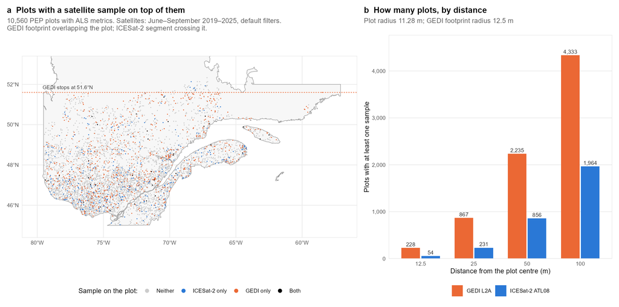

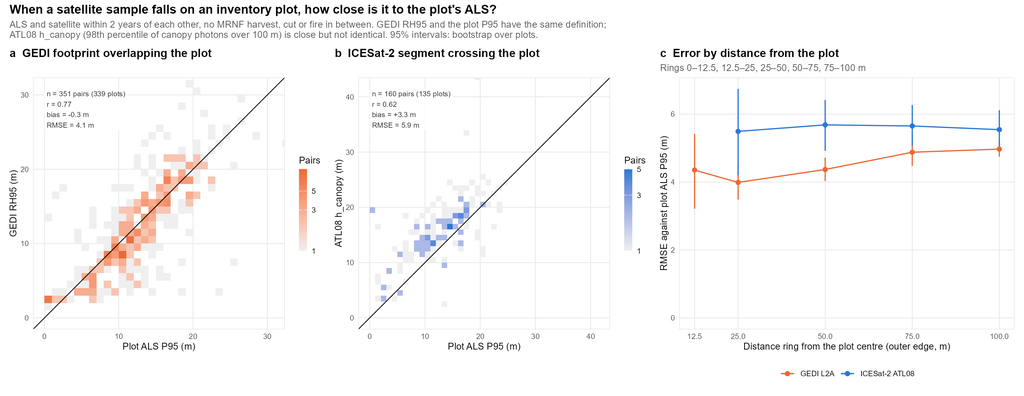

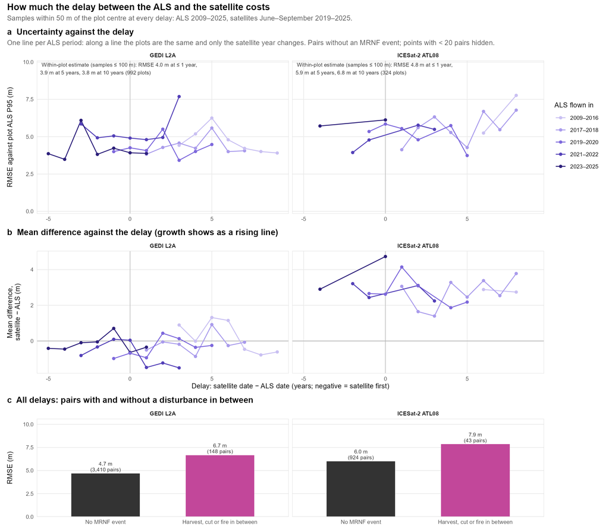

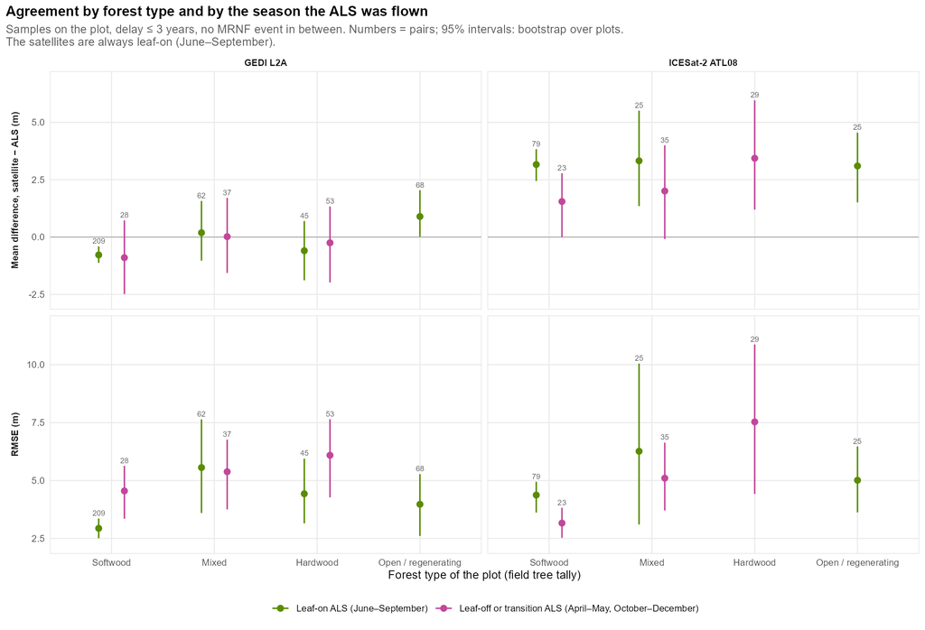

Every number quoted in pages 5 and 7 of the tutorial:

```r
cat(readLines("outputs/numbers.txt"), sep = "\n")
```

```
Plots with ALS metrics: 10,560 (south of 51.6N: 10,457)
Pairs within 100 m after filters: GEDI 13,732 (4,333 plots), ATL08 3,895 (1,964 plots)
GEDI L2A within 12.5 m: 228 plots, 232 pairs
ICESat-2 ATL08 within 12.5 m: 54 plots, 54 pairs
GEDI L2A within 25.0 m: 867 plots, 923 pairs
ICESat-2 ATL08 within 25.0 m: 231 plots, 244 pairs
GEDI L2A within 50.0 m: 2,235 plots, 3,558 pairs
ICESat-2 ATL08 within 50.0 m: 856 plots, 967 pairs
GEDI L2A within 100.0 m: 4,333 plots, 13,732 pairs
ICESat-2 ATL08 within 100.0 m: 1,964 plots, 3,895 pairs
Plots with a sample ON the plot: GEDI 867 (923 pairs), ICESat-2 430 (538 pairs), both 35
On the plot, |delay| <= 2 y, no event. GEDI RH95 vs zq95: 339 plots, n=351, r=0.77, bias=-0.32, RMSE=4.09, MAE=2.82 | RH50 vs zq50: r=0.59, bias=+0.28, RMSE=4.66
On the plot, |delay| <= 2 y, no event. ATL08 h_canopy vs zq95: 135 plots, n=160, r=0.62, bias=+3.29, RMSE=5.94, MAE=4.28
  GEDI error quantiles (5, 25, 50, 75, 95%): -6.3, -2.2, -0.4, +1.6, +6.4; share |error| > 5 m: 15%
  ATL08 error quantiles (5, 25, 50, 75, 95%): -3.6, +1.4, +2.8, +4.9, +9.6; share |error| > 5 m: 28%
RMSE by distance ring, GEDI L2A, to 12.5 m: 4.35 m (3.21-5.42), n=96
RMSE by distance ring, GEDI L2A, to 25.0 m: 3.99 m (3.48-4.55), n=255
RMSE by distance ring, GEDI L2A, to 50.0 m: 4.37 m (4.03-4.72), n=920
RMSE by distance ring, GEDI L2A, to 75.0 m: 4.88 m (4.48-5.40), n=1494
RMSE by distance ring, GEDI L2A, to 100.0 m: 4.97 m (4.75-5.22), n=2106
RMSE by distance ring, ICESat-2 ATL08, to 25.0 m: 5.49 m (4.20-6.74), n=56
RMSE by distance ring, ICESat-2 ATL08, to 50.0 m: 5.68 m (4.92-6.42), n=228
RMSE by distance ring, ICESat-2 ATL08, to 75.0 m: 5.65 m (5.07-6.27), n=363
RMSE by distance ring, ICESat-2 ATL08, to 100.0 m: 5.54 m (5.02-6.12), n=523
Within-plot delay, GEDI L2A: 5411 pairs on 992 plots; squared error -0.22 m2/yr (95% -0.78 to 0.39) -> RMSE 4.03 m at <= 1 yr, 3.90 at 5, 3.75 at 10; difference drifts +0.01 m/yr (-0.06 to 0.08)
  GEDI L2A within 50 m: 4.2% of pairs with an MRNF event in between; RMSE 6.66 m with, 4.69 m without
Within-plot delay, ICESat-2 ATL08: 1186 pairs on 324 plots; squared error +2.29 m2/yr (95% 1.14 to 3.46) -> RMSE 4.80 m at <= 1 yr, 5.88 at 5, 6.78 at 10; difference drifts +0.20 m/yr (0.08 to 0.35)
  ICESat-2 ATL08 within 50 m: 4.4% of pairs with an MRNF event in between; RMSE 7.85 m with, 6.01 m without
Forest GEDI L2A | Hardwood | Leaf-off or transition ALS (April–May, October–December): n=53 plots=50 bias=-0.25 RMSE=6.09 RH50-zq50=+6.72
Forest GEDI L2A | Softwood | Leaf-on ALS (June–September): n=209 plots=195 bias=-0.78 RMSE=2.94 RH50-zq50=-1.18
Forest GEDI L2A | Open / regenerating | Leaf-on ALS (June–September): n=68 plots=64 bias=+0.90 RMSE=3.98 RH50-zq50=-0.40
Forest GEDI L2A | Softwood | Leaf-off or transition ALS (April–May, October–December): n=28 plots=28 bias=-0.90 RMSE=4.55 RH50-zq50=-0.41
Forest GEDI L2A | Mixed | Leaf-on ALS (June–September): n=62 plots=62 bias=+0.19 RMSE=5.56 RH50-zq50=-0.81
Forest GEDI L2A | Hardwood | Leaf-on ALS (June–September): n=45 plots=44 bias=-0.60 RMSE=4.43 RH50-zq50=-1.74
Forest GEDI L2A | Mixed | Leaf-off or transition ALS (April–May, October–December): n=37 plots=36 bias=+0.02 RMSE=5.38 RH50-zq50=+2.60
Forest ICESat-2 ATL08 | Open / regenerating | Leaf-on ALS (June–September): n=25 plots=25 bias=+3.10 RMSE=5.01 RH50-zq50=NA
Forest ICESat-2 ATL08 | Softwood | Leaf-on ALS (June–September): n=79 plots=62 bias=+3.16 RMSE=4.37 RH50-zq50=NA
Forest ICESat-2 ATL08 | Hardwood | Leaf-off or transition ALS (April–May, October–December): n=29 plots=26 bias=+3.44 RMSE=7.53 RH50-zq50=NA
Forest ICESat-2 ATL08 | Mixed | Leaf-off or transition ALS (April–May, October–December): n=35 plots=26 bias=+2.01 RMSE=5.10 RH50-zq50=NA
Forest ICESat-2 ATL08 | Softwood | Leaf-off or transition ALS (April–May, October–December): n=23 plots=16 bias=+1.55 RMSE=3.16 RH50-zq50=NA
Forest ICESat-2 ATL08 | Mixed | Leaf-on ALS (June–September): n=25 plots=23 bias=+3.32 RMSE=6.26 RH50-zq50=NA
```

# Steps 9–11. Why? The same ground, footprint by footprint

In one region (UPE 14–15, `data/study_area/`), the ALS is cut to the exact ground of each satellite sample. Page 6 of the tutorial explains the results. With `run_why = false`, steps 9 and 10 are skipped and step 11 uses the tables provided in `data/why/`. With `run_why = true`, step 2 needs `data/derived/plot_tiles.csv` from step 1 for the tile URLs.

## Step 9. Satellite samples inside the region’s ALS tiles

The 306 LAZ tiles, with the code of step 2 restricted to the list:

```r
Sys.setenv(TILE_LIST = "data/derived/why/tiles_needed.csv")
```

```r
Sys.unsetenv("TILE_LIST")
```

Then the samples inside the tiles, their nearest plot and the MRNF events after the flight (the chunks above ran it first with `--tiles-only`):

```python
"""
09_footprint_inputs.py - inputs for checking ICESat-2 / GEDI against airborne lidar (ALS) on the exact ground of
each satellite sample, in one region: the UPE 14-15 study area (data/study_area/, 12,644 km2, ALS 2017-2018).

Author:    João Paulo Czarnecki de Liz (developer)
Co-author: Claude (Anthropic), AI coding assistant
Licence:   MIT (see LICENSE)

Two passes:
  --tiles-only  lists the ALS tiles that hold the region's plots (data/derived/why/tiles_needed.csv), to download
                them with   TILE_LIST=data/derived/why/tiles_needed.csv Rscript scripts/02_download_laz.R
  (default)     once the tiles are on disk, builds the tables below.

What it builds (all in data/derived/why/):
  plots_upe.csv      one row per PEP plot inside the study area that has ALS metrics: plot ALS metrics
                     (data/plot_als_metrics.csv, 11.28 m plots), ALS tile and acquisition date, forest type
                     from the field tree tally closest to the satellite years, field top height, and MRNF
                     disturbances recorded after the ALS flight.
  tiles_upe.csv      the 1 km ALS tiles that hold those plots (path, EPSG, extent, acquisition dates).
  samples_gedi.csv   every downloaded GEDI L2A shot whose 25 m footprint lies wholly inside one of those tiles,
                     with the footprint centre in the tile CRS, nearest plot and post-ALS disturbance flags.
                     No quality filters applied here (leaf-off, sensitivity), so their effect can be tested.
  samples_atl08.csv  same for ICESat-2 ATL08 100 m segments (all beams, snow flag kept), with the along-track
                     direction so the 100 m x 14 m segment rectangle can be drawn in the tile CRS.
  mrnf_cache/        MRNF harvest / fire / other-disturbance polygons per tile (public WFS, cached).

Forest type (MFFP convention, live basal area of trees >= 9.1 cm dbh): R softwood >= 75 %, F hardwood >= 75 %,
M mixed otherwise; "Open / regenerating" when live basal area < 4 m2/ha.

Inputs (read-only)
  data/study_area/upe1415_study_area.shp       the region (provided)
  data/raw/PEP.gpkg                            PEP plots and tree tally (Données Québec; or set PEP_GPKG)
  data/plot_als_metrics.csv                    plot ALS metrics and tile names (provided; or your own
                                               data/derived/plot_als_metrics_full.csv from step 3)
  data/plot_mrnf_events.csv                    MRNF events under each plot (provided; or yours from step 6)
  data/derived/why/{gedi02a,atl08}.csv         satellite samples over the region, all of them, from
                                               05_get_spaceborne_lidar.py with the study area as polygon
  data/raw/laz/*.LAZ                           the region's ALS tiles (only their headers are read here)
  MRNF WFS                                     disturbance polygons per tile (public; cached in mrnf_cache/)

Run   python -I scripts/09_footprint_inputs.py --tiles-only      (seconds)
      python -I scripts/09_footprint_inputs.py                   (~10 min the first time, WFS cached after)
"""
from __future__ import annotations

import json
import os
import sqlite3
import struct
import sys
import time
import urllib.parse
import urllib.request
import warnings

import geopandas as gpd
import numpy as np
import pandas as pd
from pyproj import Transformer
from shapely.geometry import Point, Polygon, shape

warnings.filterwarnings("ignore")
ROOT = os.environ.get("EXERCISE_ROOT", ".")
OUT = os.environ.get("WHY_DIR", os.path.join(ROOT, "data", "derived", "why"))
DAT = os.environ.get("WHY_SAT_DIR", OUT)                 # where gedi02a.csv and atl08.csv of the region are
os.makedirs(os.path.join(OUT, "mrnf_cache"), exist_ok=True)

PEP = os.environ.get("PEP_GPKG", os.path.join(ROOT, "data", "raw", "PEP.gpkg"))
LAZ = os.environ.get("LAZ_DIR", os.path.join(ROOT, "data", "raw", "laz"))
AREA = os.path.join(ROOT, "data", "study_area", "upe1415_study_area.shp")
_own = os.path.join(ROOT, "data", "derived", "plot_als_metrics_full.csv")
ALS_TABLE = _own if os.path.exists(_own) else os.path.join(ROOT, "data", "plot_als_metrics.csv")
_ev = os.path.join(ROOT, "data", "derived", "plot_mrnf_events.csv")
EVENTS = _ev if os.path.exists(_ev) else os.path.join(ROOT, "data", "plot_mrnf_events.csv")
TILES_ONLY = "--tiles-only" in sys.argv
WFS = "https://geoegl.msp.gouv.qc.ca/ws/mffpecofor.fcgi"
LAYERS = ["ca_interv_for_close_scale", "ca_feu_close_scale", "ca_perturb_autre_close_scale"]

GEDI_R = 12.5            # GEDI footprint radius (m)
SEG_HALF_L, SEG_HALF_W = 50.0, 7.0   # ATL08 segment: 100 m along track x ~14 m (footprint width)
SOFTWOOD = {"SAB", "EPN", "EPB", "EPR", "EPO", "PIG", "PIB", "PIR", "PIS", "PRU", "THO", "MEL", "MEH", "MEJ", "MEU"}
LIVE = {"10", "12", "30", "32", "40", "42", "50", "52"}   # PEP etat codes for live trees
ALS_METRICS = ["pt_density_m2", "zmax", "zmean", "zq25", "zq50", "zq75", "zq90", "zq95", "pzabove2", "pzabove5",
               "canopy_cover_2m_fr", "p_overstory_10plus", "zsd"]


def log(*a):
    print(*a, flush=True)


# ---------------------------------------------------------------- plots in the study area -------------------
area = gpd.read_file(AREA).to_crs(2950)              # NAD83(CSRS) / Quebec Lambert
pl = gpd.read_file(PEP, layer="placette").to_crs(area.crs)
pl = gpd.sjoin(pl, area[["geometry"]], predicate="within").drop(columns="index_right")
pl["plot_id"] = pl.id_pe.astype(np.int64)
als = pd.read_csv(ALS_TABLE)
if "status" in als.columns:
    als = als[als.status == "ok"]
als = als[als.plot_id.isin(pl.plot_id)].copy()
if "tile_file_name" not in als.columns:
    als["tile_file_name"] = als.NOM_TUILE + ".LAZ"
metrics = [m for m in ALS_METRICS if m in als.columns]
plots = pl[["plot_id", "id_pe", "geometry"]].merge(
    als[["plot_id", "latitude", "longitude", "CODE_EPSG", "DATES_ACQUISITION", "tile_file_name"] + metrics], on="plot_id")
plots["x2950"], plots["y2950"] = plots.geometry.x, plots.geometry.y
plots["als_date"] = plots.DATES_ACQUISITION.str.split(",").str[0]
plots["als_date_last"] = plots.DATES_ACQUISITION.str.split(",").str[-1]
log(f"{len(pl)} PEP plots in the area, {len(plots)} with ALS metrics ({ALS_TABLE})")
if TILES_ONLY:
    need = plots[["tile_file_name"]].drop_duplicates()
    need.to_csv(os.path.join(OUT, "tiles_needed.csv"), index=False)
    log(f"{len(need)} tiles listed in {os.path.join(OUT, 'tiles_needed.csv')}")
    sys.exit(0)
```

```python
# ---------------------------------------------------------------- field: forest type + top height ----------
con = sqlite3.connect(PEP)
ids = "','".join(plots.id_pe)
mes = pd.read_sql(f"select id_pe, id_pe_mes, no_mes, date_sond from placette_mes where id_pe in ('{ids}')", con)
mes["field_year"] = mes.date_sond.str[:4].astype(int)
# measurement closest to the satellite years: the latest one from 2015 on, else the latest available
mes = mes.sort_values(["id_pe", "no_mes"])
pick = mes[mes.field_year >= 2015].groupby("id_pe").tail(1)
pick = pd.concat([pick, mes[~mes.id_pe.isin(pick.id_pe)].groupby("id_pe").tail(1)])
tr = pd.read_sql(f"select id_pe_mes, etat, essence, dhp, st_ha from dendro_arbres where id_pe in ('{ids}')", con)
tr = tr[tr.id_pe_mes.isin(pick.id_pe_mes) & tr.etat.isin(LIVE)]
tr["soft"] = tr.essence.isin(SOFTWOOD)
ba = tr.groupby("id_pe_mes").agg(ba_live=("st_ha", "sum"), n_live=("st_ha", "size"))
ba["ba_soft"] = tr[tr.soft].groupby("id_pe_mes").st_ha.sum()
ba["ba_soft"] = ba.ba_soft.fillna(0)
dom = tr.groupby(["id_pe_mes", "essence"]).st_ha.sum().reset_index().sort_values("st_ha") \
    .groupby("id_pe_mes").tail(1).set_index("id_pe_mes").essence
ba["dom_species"] = dom
ba["soft_share"] = ba.ba_soft / ba.ba_live
et = pd.read_sql(f"select id_pe_mes, etat, haut_arbre from dendro_arbres_etudes where id_pe in ('{ids}')", con)
et = et[et.id_pe_mes.isin(pick.id_pe_mes) & et.etat.isin(LIVE) & et.haut_arbre.notna()]
et["h"] = et.haut_arbre / 10.0                                   # decimetres -> m
top = et.sort_values("h").groupby("id_pe_mes").h.apply(lambda v: v.tail(3).mean()).rename("field_htop")
hmax = et.groupby("id_pe_mes").h.max().rename("field_hmax")
nh = et.groupby("id_pe_mes").h.size().rename("field_n_heights")
fld = pick.set_index("id_pe_mes").join([ba, top, hmax, nh]).reset_index()


def ftype(r):
    if pd.isna(r.ba_live) or r.ba_live < 4:
        return "Open / regenerating"
    if r.soft_share >= 0.75:
        return "Softwood"
    if r.soft_share <= 0.25:
        return "Hardwood"
    return "Mixed"


fld["forest_type"] = fld.apply(ftype, axis=1)
plots = plots.merge(fld[["id_pe", "field_year", "no_mes", "ba_live", "soft_share", "dom_species", "forest_type",
                         "field_htop", "field_hmax", "field_n_heights"]], on="id_pe", how="left")
log(plots.forest_type.value_counts().to_dict())

# ---------------------------------------------------------------- disturbance after the ALS flight ----------
ev = pd.read_csv(EVENTS)
ev = ev[ev.plot_id.isin(plots.plot_id) & (ev.overlap >= 0.5)].copy()
ev["year"] = ev.an_perturb.fillna(ev.an_origine).fillna(ev.exercice)
ev = ev.merge(plots[["plot_id", "als_date"]], on="plot_id")
ev = ev[ev.year >= ev.als_date.str[:4].astype(int)]          # same year counted: it may postdate the flight
ev["kind"] = np.where(ev.layer == "ca_feu_close_scale", "fire",
                      np.where(ev.layer == "ca_interv_for_close_scale",
                               np.where(ev.origine.notna(), "harvest (stand-replacing)", "partial cut / tending"),
                               "other natural"))
post = ev.groupby("plot_id").agg(post_als_event=("kind", lambda k: "; ".join(sorted(set(k)))),
                                 post_als_year=("year", "min"))
plots = plots.merge(post, on="plot_id", how="left")
plots["post_als_event"] = plots.post_als_event.fillna("none")
log("plots disturbed after ALS:", (plots.post_als_event != "none").sum())

# ---------------------------------------------------------------- tiles ------------------------------------
def las_header(path):
    """Point count and extent from the LAS/LAZ public header (the header of a LAZ file is not compressed)."""
    with open(path, "rb") as fh:
        h = fh.read(255)
    minor = h[25]
    n = struct.unpack("<I", h[107:111])[0]
    if minor >= 4 and n == 0:
        n = struct.unpack("<Q", h[247:255])[0]
    xmax, xmin, ymax, ymin = struct.unpack("<4d", h[179:211])
    return n, xmin, xmax, ymin, ymax


tiles = plots[["tile_file_name", "CODE_EPSG", "DATES_ACQUISITION"]].drop_duplicates("tile_file_name").copy()
tiles["path"] = [os.path.abspath(os.path.join(LAZ, f)) for f in tiles.tile_file_name]
missing = int((~tiles.path.map(os.path.exists)).sum())
if missing:
    log(f"WARNING: {missing} of {len(tiles)} tiles are not in {LAZ}; their plots and samples are left out")
tiles = tiles[tiles.path.map(os.path.exists)].copy()
hdr = [las_header(p) for p in tiles.path]
for k, c in enumerate(["hdr_npoints", "hdr_xmin", "hdr_xmax", "hdr_ymin", "hdr_ymax"]):
    tiles[c] = [h[k] for h in hdr]
tiles["empirical_density_pts_m2"] = tiles.hdr_npoints / ((tiles.hdr_xmax - tiles.hdr_xmin) * (tiles.hdr_ymax - tiles.hdr_ymin))
plots = plots[plots.tile_file_name.isin(tiles.tile_file_name)]
tiles["als_date"] = tiles.DATES_ACQUISITION.str.split(",").str[0]
log(f"{len(tiles)} tiles, {tiles.hdr_npoints.sum() / 1e9:.2f} G points")

# ---------------------------------------------------------------- satellite samples inside tiles -----------
TR = {e: Transformer.from_crs(4326, int(e), always_xy=True) for e in tiles.CODE_EPSG.unique()}


def to_tile_xy(d, epsg):
    return TR[epsg].transform(d.lon.values, d.lat.values)


def assign(d, kind):
    """Return the rows of d whose whole footprint lies inside a tile, with tile id and tile-CRS coordinates."""
    out = []
    for epsg, tg in tiles.groupby("CODE_EPSG"):
        x, y = to_tile_xy(d, epsg)
        dd = d.assign(x_tile=x, y_tile=y)
        if kind == "atl08":
            ux, uy = dd[f"ux_{epsg}"].values, dd[f"uy_{epsg}"].values
            # half-extent of the rotated rectangle along x and y
            ex = np.abs(ux) * SEG_HALF_L + np.abs(uy) * SEG_HALF_W
            ey = np.abs(uy) * SEG_HALF_L + np.abs(ux) * SEG_HALF_W
        else:
            ex = ey = np.full(len(dd), GEDI_R)
        for t in tg.itertuples():
            m = (x - ex >= t.hdr_xmin + 1) & (x + ex <= t.hdr_xmax - 1) & (y - ey >= t.hdr_ymin + 1) & (y + ey <= t.hdr_ymax - 1)
            if m.any():
                s = dd[m].copy()
                s["tile_file_name"], s["tile_epsg"] = t.tile_file_name, int(epsg)
                if kind == "atl08":
                    s["ux"], s["uy"] = s[f"ux_{epsg}"], s[f"uy_{epsg}"]
                out.append(s)
    r = pd.concat(out, ignore_index=True)
    return r.drop(columns=[c for c in r.columns if c.startswith(("ux_", "uy_"))])
```

```python
# GEDI L2A, no filters
g = pd.read_csv(os.path.join(DAT, "gedi02a.csv"))
g = g[(g.lon > -80) & (g.lat > 44)]
gs = assign(g, "gedi")
log(f"GEDI L2A shots inside tiles: {len(gs)} (of {len(g)})")

# ATL08: along-track direction from neighbouring segments of the same beam and date, in each tile CRS
a = pd.read_csv(os.path.join(DAT, "atl08.csv"))
a["date"] = a.time_ns.str[:10]
a = a.sort_values(["rgt", "cycle", "gt", "date", "segment_id_beg"]).reset_index(drop=True)
for epsg in tiles.CODE_EPSG.unique():
    x, y = to_tile_xy(a, epsg)
    a["_x"], a["_y"] = x, y
    grp = a.groupby(["rgt", "cycle", "gt", "date"])
    dx = grp._x.shift(-1) - grp._x.shift(1)
    dy = grp._y.shift(-1) - grp._y.shift(1)
    dx = dx.fillna(grp._x.shift(-1) - a._x).fillna(a._x - grp._x.shift(1))
    dy = dy.fillna(grp._y.shift(-1) - a._y).fillna(a._y - grp._y.shift(1))
    L = np.hypot(dx, dy)
    ok = (L > 0) & (L < 500)                         # neighbours more than 500 m away are another stretch
    a[f"ux_{epsg}"] = np.where(ok, dx / L, np.nan)
    a[f"uy_{epsg}"] = np.where(ok, dy / L, np.nan)
    # isolated segments: use the median direction of their beam on that date
    for c in (f"ux_{epsg}", f"uy_{epsg}"):
        a[c] = a[c].fillna(a.groupby(["rgt", "cycle", "gt", "date"])[c].transform("median"))
a = a.drop(columns=["_x", "_y"])
a = a[a[[c for c in a.columns if c.startswith("ux_")]].notna().all(axis=1)]
as_ = assign(a, "atl08")
log(f"ATL08 segments inside tiles: {len(as_)} (of {len(a)})")

# ---------------------------------------------------------------- nearest plot -----------------------------
t2950 = Transformer.from_crs(4326, 2950, always_xy=True)
pp = gpd.GeoDataFrame(plots[["plot_id", "forest_type"]], geometry=gpd.points_from_xy(plots.x2950, plots.y2950), crs=2950)
for s in (gs, as_):
    x, y = t2950.transform(s.lon.values, s.lat.values)
    s["x2950"], s["y2950"] = x, y
    sp = gpd.GeoDataFrame({"row": np.arange(len(s))}, geometry=gpd.points_from_xy(x, y), crs=2950)
    nn = gpd.sjoin_nearest(sp, pp, distance_col="d").drop_duplicates("row").sort_values("row")
    s["near_plot"], s["near_plot_dist"] = nn.plot_id.values, nn.d.values
    s["near_forest_type"] = nn.forest_type.values


# ---------------------------------------------------------------- MRNF disturbance polygons per tile --------
def wfs_tile(t):
    """Harvest / fire / other polygons intersecting the tile (EPSG:4326 bbox), cached as GeoJSON."""
    path = os.path.join(OUT, "mrnf_cache", t.tile_file_name.replace(".LAZ", ".json"))
    if os.path.exists(path):
        with open(path, encoding="utf-8") as fh:
            return json.load(fh)
    inv = Transformer.from_crs(int(t.CODE_EPSG), 4326, always_xy=True)
    lo, la = inv.transform([t.hdr_xmin, t.hdr_xmax, t.hdr_xmin, t.hdr_xmax], [t.hdr_ymin, t.hdr_ymin, t.hdr_ymax, t.hdr_ymax])
    feats = []
    for layer in LAYERS:
        q = urllib.parse.urlencode({"service": "WFS", "version": "2.0.0", "request": "GetFeature",
                                    "typeNames": f"ms:{layer}", "outputFormat": "geojson",
                                    "bbox": f"{min(la)},{min(lo)},{max(la)},{max(lo)},urn:ogc:def:crs:EPSG::4326"})
        for attempt in range(4):
            try:
                with urllib.request.urlopen(f"{WFS}?{q}", timeout=120) as r:
                    js = json.loads(r.read().decode("utf-8"))
                break
            except Exception as e:  # noqa: BLE001
                if attempt == 3:
                    raise
                time.sleep(5 * (attempt + 1))
        for f in js.get("features", []):
            f["properties"]["layer"] = layer
            feats.append(f)
    out = {"type": "FeatureCollection", "features": feats}
    with open(path, "w", encoding="utf-8") as fh:
        json.dump(out, fh)
    return out


log("MRNF disturbance polygons per tile (cached after the first run)...")
polys = []
for i, t in enumerate(tiles.itertuples()):
    js = wfs_tile(t)
    for f in js["features"]:
        p = f["properties"]
        yr = p.get("an_perturb") or p.get("an_origine") or p.get("exercice")
        try:
            yr = int(float(yr))
        except (TypeError, ValueError):
            continue
        geom = shape(f["geometry"])
        if not geom.is_valid:
            geom = geom.buffer(0)
        kind = ("fire" if p["layer"] == "ca_feu_close_scale" else
                ("harvest (stand-replacing)" if p.get("origine") else "partial cut / tending")
                if p["layer"] == "ca_interv_for_close_scale" else "other natural")
        polys.append({"year": yr, "kind": kind, "code": p.get("origine") or p.get("perturb"), "geometry": geom})
    if (i + 1) % 50 == 0:
        log(f"  {i + 1}/{len(tiles)} tiles")
dist = gpd.GeoDataFrame(polys, crs=4326).to_crs(2950) if polys else gpd.GeoDataFrame(columns=["year", "kind", "geometry"], crs=2950)
dist = dist[dist.year >= tiles.als_date.str[:4].astype(int).min() - 1]   # only what can postdate the flights matters
dist.to_file(os.path.join(OUT, "mrnf_disturbance_after_als.gpkg"), driver="GPKG")
log(f"{len(dist)} MRNF polygons dated from the year before the first flight on")


def flag_post_als(s, kind):
    """Earliest MRNF event (year >= ALS year) intersecting each footprint."""
    if kind == "gedi":
        geo = gpd.GeoSeries(gpd.points_from_xy(s.x2950, s.y2950), crs=2950).buffer(GEDI_R)
    else:  # rectangle in EPSG:2950 (direction from the tile CRS; the rotation between MTM 8 and 9 is < 1 degree)
        ux, uy = s.ux.values, s.uy.values
        cx, cy = s.x2950.values, s.y2950.values
        geo = gpd.GeoSeries([Polygon([(x - SEG_HALF_L * a_ - SEG_HALF_W * b_, y - SEG_HALF_L * b_ + SEG_HALF_W * a_),
                                      (x + SEG_HALF_L * a_ - SEG_HALF_W * b_, y + SEG_HALF_L * b_ + SEG_HALF_W * a_),
                                      (x + SEG_HALF_L * a_ + SEG_HALF_W * b_, y + SEG_HALF_L * b_ - SEG_HALF_W * a_),
                                      (x - SEG_HALF_L * a_ + SEG_HALF_W * b_, y - SEG_HALF_L * b_ - SEG_HALF_W * a_)])
                             for x, y, a_, b_ in zip(cx, cy, ux, uy)], crs=2950)
    fp = gpd.GeoDataFrame({"row": np.arange(len(s))}, geometry=geo.values, crs=2950)
    als_year = s.tile_file_name.map(tiles.set_index("tile_file_name").als_date.str[:4].astype(int)).values
    j = gpd.sjoin(fp, dist[["year", "kind", "geometry"]], predicate="intersects")
    j = j[j.year.values >= als_year[j.row.values]]
    first = j.sort_values(["year", "kind"], kind="stable").groupby("row").first()   # same year: fire, then harvest, then the rest
    s["post_als_event"] = "none"
    s.loc[s.index[first.index], "post_als_event"] = first.kind.values
    s["post_als_year"] = np.nan
    s.loc[s.index[first.index], "post_als_year"] = first.year.values
    return s
```

```python
gs = flag_post_als(gs.reset_index(drop=True), "gedi")
as_ = flag_post_als(as_.reset_index(drop=True), "atl08")
log("GEDI post-ALS:", gs.post_als_event.value_counts().to_dict())
log("ATL08 post-ALS:", as_.post_als_event.value_counts().to_dict())

# ---------------------------------------------------------------- write ------------------------------------
plots.drop(columns="geometry").to_csv(os.path.join(OUT, "plots_upe.csv"), index=False)
plots[["plot_id", "forest_type", "geometry"]].to_file(os.path.join(OUT, "plots_upe.gpkg"), driver="GPKG")
tiles.to_csv(os.path.join(OUT, "tiles_upe.csv"), index=False)
gs.to_csv(os.path.join(OUT, "samples_gedi.csv"), index=False)
as_.to_csv(os.path.join(OUT, "samples_atl08.csv"), index=False)
log("wrote", OUT)
```

```r
check_step(9)
```

```
Step 9
  [PASS] study area polygon
  [PASS] region download gedi02a.csv - 726,381 rows
  [PASS] region download atl08.csv - 223,462 rows
  [PASS] region plots with ALS and forest type - 410 plots in 306 tiles
  [PASS] every plot's tile is listed
  [PASS] GEDI footprints wholly inside their tile - 18,094 footprints
  [PASS] ATL08 along-track direction is a unit vector - 4,784 segments
  [PASS] post-ALS events flagged - GEDI 8.0% with an event
```

## Step 10. ALS on the ground of each footprint

```r
###############################################################################
# 10_als_at_footprints.R - airborne lidar (ALS) equivalents of the ICESat-2 and GEDI metrics, computed on the
# exact ground each satellite sample covers, in the ALS tiles that hold the PEP plots of the UPE 14-15 region.
#
# Author:    João Paulo Czarnecki de Liz (developer)
# Co-author: Claude (Anthropic), AI coding assistant
# Licence:   MIT (see LICENSE)
#
# For every tile: read the LAZ (provider classification: 2 = ground), normalise heights with a TIN of the
# ground returns, floor heights at 0 and drop returns above 60 m, then clip
#   * each GEDI footprint: circle of 12.5 m radius around the shot centre
#   * each ATL08 segment:  rectangle 100 m along track x 14 m across, centred on the segment
#   * each PEP plot:       circle of 11.28 m (check against data/plot_als_metrics.csv, which used CSF ground)
# and compute the ALS version of each satellite metric:
#   GEDI RHxx      <-> ALS percentile xx of ALL return heights (ground included; RH is relative to the ground
#                      return, like the ALS heights) - als_rh10 ... als_rh100
#   ATL08 h_canopy <-> ALS 98th percentile of CANOPY returns (> 0.5 m, where ATL08 starts calling photons canopy),
#                      als_p98_can; ch_p50 <-> als_p50_can; h_mean_canopy <-> als_mean_can; same with > 2 m in
#                      als_*_can2; segment with no canopy photons <-> fewer than 3 canopy returns
#   cover          <-> ALS first returns > 2 m / all first returns (als_cover2); > 5 m (als_cover5)
#
# Input   data/derived/why/tiles_upe.csv, samples_gedi.csv, samples_atl08.csv, plots_upe.csv (09_footprint_inputs.py)
# Output  data/derived/why/als_at_gedi.csv, als_at_atl08.csv, als_at_plots_check.csv, als_tile_wall_to_wall.csv
#         (1 m CHM summary per tile) and als_cache/<tile>_chm_dm.tif (the CHM, in decimetres)
# Run     WORKERS=6 Rscript scripts/10_als_at_footprints.R           (~4.5 h for 306 tiles, 23.5 GB of LAZ;
#         one cache file per tile, so it resumes after a stop)
#         TILE_LIMIT=3 Rscript scripts/10_als_at_footprints.R        (a quick try on 3 tiles)
###############################################################################
suppressPackageStartupMessages({ library(lidR); library(data.table); library(parallel) })
ROOT <- Sys.getenv("EXERCISE_ROOT", ".")
WORKERS <- as.integer(Sys.getenv("WORKERS", "6"))
NTILES  <- as.integer(Sys.getenv("TILE_LIMIT", "0")); if (NTILES <= 0) NTILES <- Inf
OUT <- Sys.getenv("WHY_DIR", file.path(ROOT, "data/derived/why"))
CACHE <- Sys.getenv("WHY_CACHE", file.path(OUT, "als_cache")); dir.create(CACHE, showWarnings = FALSE, recursive = TRUE)

tiles <- fread(file.path(OUT, "tiles_upe.csv"))
gedi  <- fread(file.path(OUT, "samples_gedi.csv"),  select = c("time", "beam", "tile_file_name", "x_tile", "y_tile"), colClasses = list(character = "time"))
atl   <- fread(file.path(OUT, "samples_atl08.csv"), select = c("time_ns", "rgt", "cycle", "gt", "segment_id_beg",
                                                               "tile_file_name", "x_tile", "y_tile", "ux", "uy"), colClasses = list(character = "time_ns"))
plots <- fread(file.path(OUT, "plots_upe.csv"), select = c("plot_id", "tile_file_name", "latitude", "longitude",
                                                           "CODE_EPSG"))
tiles <- tiles[order(-(tile_file_name %in% c(gedi$tile_file_name, atl$tile_file_name)))]
if (is.finite(NTILES)) tiles <- tiles[seq_len(min(NTILES, .N))]

one_tile <- function(t, gedi, atl, plots, CACHE) {
  suppressPackageStartupMessages({ library(lidR); library(data.table); library(sf) })
  set_lidr_threads(1L); options(lidR.progress = FALSE)
  f <- file.path(CACHE, sub("\\.LAZ$", ".rds", t$tile_file_name))
  if (file.exists(f) && identical(readRDS(f)$version, 2L)) return(f)   # reuse caches of this version only
  t0 <- Sys.time()
  g <- gedi[tile_file_name == t$tile_file_name]; a <- atl[tile_file_name == t$tile_file_name]
  p <- plots[tile_file_name == t$tile_file_name]
  las <- readLAS(t$path, select = "xyzrnc", filter = "-drop_withheld -drop_class 7 18")
  res <- list(tile = t$tile_file_name, version = 2L, status = "ok", gedi = NULL, atl = NULL, plots = NULL)
  if (is.empty(las) || sum(las$Classification == 2L) < 100) {
    res$status <- "no_ground"; saveRDS(res, f); return(f)
  }
  las <- normalize_height(las, tin(), use_class = 2L)
  las <- filter_poi(las, Z >= -2, Z <= 60)
  las$Z[las$Z < 0] <- 0
  # GEDI-like metrics: percentiles of all returns, first-return cover
  mg <- function(z, rn) {
    q <- quantile(z, c(.10, .25, .50, .75, .90, .95, .98, 1), names = FALSE)
    fr <- z[rn == 1L]
    list(als_n = length(z), als_rh10 = q[1], als_rh25 = q[2], als_rh50 = q[3], als_rh75 = q[4], als_rh90 = q[5],
         als_rh95 = q[6], als_rh98 = q[7], als_rh100 = q[8],
         als_cover2 = if (length(fr)) mean(fr > 2) else NA_real_, als_cover5 = if (length(fr)) mean(fr > 5) else NA_real_,
         als_frac2 = mean(z > 2))
  }
  # ATL08-like metrics: percentiles of canopy returns. ATL08 labels photons from ~0.5 m above the ground as
  # canopy (median h_min_canopy 0.64 m here), so returns > 0.5 m are the main counterpart; > 2 m kept to compare
  ma <- function(z, rn) {
    fr <- z[rn == 1L]
    can <- function(thr, sfx) {
      cz <- z[z > thr]
      qc <- if (length(cz) >= 3) quantile(cz, c(.25, .50, .75, .98), names = FALSE) else rep(NA_real_, 4)
      setNames(list(length(cz), qc[1], qc[2], qc[3], qc[4], if (length(cz) >= 3) mean(cz) else NA_real_),
               paste0(c("als_n_can", "als_p25_can", "als_p50_can", "als_p75_can", "als_p98_can", "als_mean_can"), sfx))
    }
    c(list(als_n = length(z)), can(0.5, ""), can(2, "2"),
      list(als_max = max(z), als_p98_all = quantile(z, .98, names = FALSE),
           als_cover2 = if (length(fr)) mean(fr > 2) else NA_real_, als_cover5 = if (length(fr)) mean(fr > 5) else NA_real_,
           als_frac2 = mean(z > 2)))
  }
  run_clips <- function(clips, fun) rbindlist(lapply(clips, function(l) {
    if (is.null(l) || is.empty(l)) return(data.table(als_n = 0L)) else as.data.table(fun(l$Z, l$ReturnNumber))
  }), fill = TRUE)
  if (nrow(g)) {
    cl <- clip_circle(las, g$x_tile, g$y_tile, 12.5)
    if (inherits(cl, "LAS")) cl <- list(cl)
    res$gedi <- cbind(g[, .(time, beam)], run_clips(cl, mg))
  }
  if (nrow(a)) {
    rect <- lapply(seq_len(nrow(a)), function(i) {
      cx <- a$x_tile[i]; cy <- a$y_tile[i]; ux <- a$ux[i]; uy <- a$uy[i]; L <- 50; W <- 7
      m <- rbind(c(cx - L * ux - W * uy, cy - L * uy + W * ux), c(cx + L * ux - W * uy, cy + L * uy + W * ux),
                 c(cx + L * ux + W * uy, cy + L * uy - W * ux), c(cx - L * ux + W * uy, cy - L * uy - W * ux))
      st_polygon(list(rbind(m, m[1, ])))
    })
    cl <- clip_roi(las, st_sfc(rect, crs = st_crs(las)))
    if (inherits(cl, "LAS")) cl <- list(cl)
    res$atl <- cbind(a[, .(time_ns, rgt, cycle, gt, segment_id_beg)], run_clips(cl, ma))
  }
  if (nrow(p)) {
    xy <- st_coordinates(st_transform(st_as_sf(p, coords = c("longitude", "latitude"), crs = 4326), st_crs(las)))
    cl <- clip_circle(las, xy[, 1], xy[, 2], 11.28)
    if (inherits(cl, "LAS")) cl <- list(cl)
    res$plots <- cbind(p[, .(plot_id)], run_clips(cl, mg))
  }
  # wall-to-wall reference for the tile: 1 m canopy height model (highest return per cell) and first returns
  chm <- rasterize_canopy(las, res = 1, algorithm = p2r(0.2))
  v <- terra::values(chm, mat = FALSE); v <- v[!is.na(v)]
  fr <- las$Z[las$ReturnNumber == 1L]
  res$tile_stats <- data.table(chm_cells = length(v), chm_cover2 = mean(v > 2), chm_cover5 = mean(v > 5),
                               chm_med_can = median(v[v > 2]), chm_p90_can = quantile(v[v > 2], 0.9, names = FALSE),
                               fr_cover2 = mean(fr > 2), fr_cover5 = mean(fr > 5), n_points = npoints(las))
  terra::writeRaster(round(chm * 10), file.path(CACHE, sub("\\.LAZ$", "_chm_dm.tif", t$tile_file_name)),
                     datatype = "INT2U", gdal = c("COMPRESS=DEFLATE"), overwrite = TRUE)
  res$seconds <- as.numeric(difftime(Sys.time(), t0, units = "secs"))
  saveRDS(res, f); rm(las); gc(verbose = FALSE)
  f
}

cat(sprintf("%d tiles, %d GEDI shots, %d ATL08 segments, %d plots; %d workers\n",
            nrow(tiles), nrow(gedi), nrow(atl), nrow(plots), WORKERS))
tl <- split(tiles, seq_len(nrow(tiles)))
t_start <- Sys.time()
if (WORKERS > 1) {
  cl <- makeCluster(WORKERS)
  files <- parLapplyLB(cl, tl, one_tile, gedi = gedi, atl = atl, plots = plots, CACHE = CACHE)
  stopCluster(cl)
} else files <- lapply(tl, one_tile, gedi = gedi, atl = atl, plots = plots, CACHE = CACHE)
cat(sprintf("extraction: %.1f min\n", as.numeric(difftime(Sys.time(), t_start, units = "mins"))))

R <- lapply(unlist(files), readRDS)
cat("tile status:", paste(names(table(sapply(R, `[[`, "status"))), table(sapply(R, `[[`, "status")), collapse = " "),
    "| median s per tile:", round(median(unlist(lapply(R, `[[`, "seconds")), na.rm = TRUE), 1), "\n")
bind <- function(k) rbindlist(lapply(R, function(r) if (!is.null(r[[k]])) cbind(tile_file_name = r$tile, r[[k]])), fill = TRUE)
fwrite(bind("gedi"),  file.path(OUT, "als_at_gedi.csv"))
fwrite(bind("atl"),   file.path(OUT, "als_at_atl08.csv"))
fwrite(bind("plots"), file.path(OUT, "als_at_plots_check.csv"))
fwrite(bind("tile_stats"), file.path(OUT, "als_tile_wall_to_wall.csv"))
cat("wrote als_at_gedi.csv, als_at_atl08.csv, als_at_plots_check.csv, als_tile_wall_to_wall.csv\n")
```

```r
check_step(10)
```

```
Step 10
  [PASS] ALS computed for the GEDI footprints - 18,094 of 18,094
  [PASS] GEDI footprints with enough ALS returns - 99.7%
  [PASS] ALS heights within 0-60 m
  [PASS] plot P95 matches the ALS table (same LAZ, other ground filter) - RMSE 0.13 m over 410 plots
```